[figure not shown]

# AI Adoption and Job-Market Demand: Time-Series Analysis

Data analytics, software, and overall U.S. job openings versus CAPEX, PPI (Information), the Federal Funds Rate, PCE, and NVIDIA revenue

Published

November 25, 2026

# 1 Introduction

The rapid growth of generative AI raises important questions about how AI adoption is reflected in labor-market demand, especially for data analytics and software roles. This analysis examines whether technology investment (CAPEX), producer prices (PPI for Information), macroeconomic conditions (the Federal Funds Rate and PCE), and NVIDIA revenue help explain and forecast changes in job openings.

**Research questions**

1. How do data analytics (DA) and software (SW) job openings differ from overall U.S. job openings (ALL) in their relationship with technology investment and macroeconomic indicators?
2. Can CAPEX, PPI (Information), the Federal Funds Rate, PCE, and NVIDIA revenue help predict changes in job-market demand for data analytics roles?

**Data**

[output not shown]

Table 1. **Data used in this analysis.** The variables, what they measure, and where they come from.

**TipPlain-English summary**

**The big question:** Do technology spending, business prices, interest rates, consumer spending, and NVIDIA’s revenue (a gauge of AI demand) help us predict how many data analytics jobs are open?

**Part 1 – Look at the data (daily).** We graph daily job openings for data analytics (DA), software (SW), and all jobs (ALL) next to company technology spending (CAPEX), the prices businesses charge in the information sector (PPI), and NVIDIA’s revenue. Then we check two things: whether the lines tend to rise and fall together, and whether one tends to move first. For example, does a change in spending show up in job postings a few weeks later?

**Part 2 – Make predictions (daily).** We build forecasting models and test them on recent days they have never seen, like a pop quiz. Simple models use only the past pattern of job openings to guess the future. Fuller models also use CAPEX and PPI, or NVIDIA’s revenue, as clues. Comparing the scores shows whether those clues improve the forecasts.

**Part 3 – Zoom out to the economy (monthly).** We switch to monthly data and ask how data analytics job openings relate to interest rates (the Federal Funds Rate), consumer spending (PCE), information-sector prices (PPI), and NVIDIA’s quarterly revenue. NVIDIA reports revenue only once a quarter, so each quarter’s figure is carried across its months to line up with the monthly data. We build the model step by step:

1. Look at the data.
2. Make sure the pattern is stable enough to model.
3. Account for seasonal patterns, such as hiring that rises and falls at the same times each year.
4. Try many model settings and keep the best.
5. Test the model repeatedly on past periods.
6. Check that its mistakes look random, meaning it hasn’t missed anything obvious.
7. Produce the final forecast of data analytics job openings.

**In short:** We look for clues, test whether they help predict job demand, and then forecast where it is heading.

# 2 Setup

```r
library(tidyverse)
library(lubridate)
library(forecast)
library(prophet)
library(patchwork)
library(broom)
library(scales)
library(knitr)
library(kableExtra)
library(tseries)
library(astsa)
library(plotly)
library(gridExtra)

# ------------------------------------------------------------
# Paths (relative to this .qmd file; keep the folder structure)
#   data/daily/    job openings, CAPEX, PPI
#   data/monthly/  FEDFUNDS, PCE, PPI (Information), DA job postings
#   data/          NVIDIA Quarterly Revenue.csv (quarterly)
# ------------------------------------------------------------

data_folder         <- file.path("data", "daily")
monthly_data_folder <- file.path("data", "monthly")
nvidia_file         <- file.path("data", "NVIDIA Quarterly Revenue.csv")

# Where figures and CSV results are saved
output_folder <- "outputs"
save_outputs  <- TRUE

dir.create(output_folder, showWarnings = FALSE, recursive = TRUE)

# ------------------------------------------------------------
# Analysis settings
# ------------------------------------------------------------

lag_max          <- 30   # maximum CCF lag (days)
test_horizon     <- 36   # final observations held out for testing (days)
forecast_horizon <- 36   # future forecast horizon (days)

# ------------------------------------------------------------
# Speed settings
# ------------------------------------------------------------

# FALSE = fast stepwise auto.arima search (seconds per model).
# TRUE  = exhaustive search (no stepwise, no approximation); much slower
#         on ~1,800 daily observations (minutes per model).
exhaustive_search <- FALSE

# TRUE = reuse fitted models saved by a previous render (outputs/model_cache).
# Set to FALSE, or delete that folder, after changing the data or settings.
reuse_saved_models <- TRUE

# ------------------------------------------------------------
# Shared labels, colors, and plot theme
# ------------------------------------------------------------

job_labels <- c(
  DA  = "DA Job Openings",
  SW  = "SW Job Openings",
  ALL = "All Job Openings"
)

job_levels <- c("All Job Openings", "DA Job Openings", "SW Job Openings")

col_actual <- "#1F5A94"
col_pred   <- "#B2182B"

theme_ts <- function(base_size = 12) {
  theme_minimal(base_size = base_size) +
    theme(
      plot.title       = element_text(face = "bold", size = 17),
      plot.subtitle    = element_text(size = 11, color = "gray35"),
      strip.text       = element_text(face = "bold", size = 10),
      panel.grid.minor = element_blank(),
      legend.position  = "bottom",
      plot.caption     = element_text(hjust = 0, face = "italic", color = "gray40")
    )
}

save_plot <- function(plot, file_name, width = 13, height = 9) {
  if (save_outputs) {
    ggsave(
      filename = file.path(output_folder, file_name),
      plot = plot, width = width, height = height, dpi = 300, bg = "white"
    )
  }
}

# Fit once, then reload the saved result on later renders
cache_folder <- file.path(output_folder, "model_cache")
dir.create(cache_folder, showWarnings = FALSE, recursive = TRUE)

cached <- function(name, expr) {
  file <- file.path(cache_folder, paste0(name, ".rds"))
  if (reuse_saved_models && file.exists(file)) {
    message("Loaded saved results: ", file)
    return(readRDS(file))
  }
  value <- expr
  saveRDS(value, file)
  value
}

save_table <- function(data, file_name) {
  if (save_outputs) {
    write_csv(data, file.path(output_folder, file_name))
  }
}
```

# 3 Data Preparation (Daily)

## 3.1 NVIDIA quarterly revenue

NVIDIA reports revenue once a quarter. Following the Ridge Regression Simulator and the Elasticity Dashboard, each quarter’s revenue (US$ millions, converted here to US$ billions) is carried forward from the month the quarter ends until the next quarter is reported. The same step series is used for the daily analysis (Parts 1 and 2) and the monthly analysis (Part 3).

```r
nvidia_q <- read.csv(nvidia_file, skip = 2, header = FALSE,
                     col.names = c("Date", "Revenue"), stringsAsFactors = FALSE) %>%
  mutate(Date          = floor_date(mdy(Date), unit = "month"),
         NVIDIARevenue = parse_number(Revenue) / 1000) %>%
  select(Date, NVIDIARevenue) %>%
  arrange(Date)

# Quarterly revenue carried forward to any date (NA before the first quarter)
nvidia_step <- function(dates) {
  idx <- findInterval(floor_date(dates, "month"), nvidia_q$Date)
  nvidia_q$NVIDIARevenue[if_else(idx == 0L, NA_integer_, idx)]
}

nvidia_q %>%
  slice_tail(n = 8) %>%
  kable(digits = 3, col.names = c("Quarter-end month", "Revenue (US$ billions)")) %>%
  kable_styling(full_width = FALSE)
```

| Quarter-end month | Revenue (US$ billions) |
| --- | --- |
| 2024-10-01 | 35.082 |
| 2025-01-01 | 39.331 |
| 2025-04-01 | 44.062 |
| 2025-07-01 | 46.743 |
| 2025-10-01 | 57.006 |
| 2026-01-01 | 68.127 |
| 2026-04-01 | 81.615 |
| 2026-07-01 | 96.221 |

Table 2. **NVIDIA revenue, most recent quarters.** Revenue is reported once per quarter, in billions of US dollars. Each value is carried forward across the following months and days so it can be lined up with the job-posting data.

## 3.2 Load and merge all sources

Each file is read, its date column is detected and parsed, and every other column is prefixed with the file name so that variables remain identifiable after merging. The datasets are then restricted to their common overlapping period.

```r
files <- c(
  "all_capex_ppi_daily_interpolated.csv",
  "indeed_data_analysis.csv",
  "indeed-all.csv",
  "indeed-software.csv"
)

read_file <- function(filename) {

  data <- read_csv(file.path(data_folder, filename), show_col_types = FALSE)

  # Find the date column
  date_col <- names(data)[grepl("date|month|time", names(data), ignore.case = TRUE)][1]

  if (is.na(date_col)) {
    stop("No date column found in: ", filename)
  }

  # Parse dates in any of the common formats
  date_values <- as.character(data[[date_col]])

  parsed_dates <- suppressWarnings(
    as.Date(
      parse_date_time(
        date_values,
        orders = c("ymd", "mdy", "dmy", "ym", "my", "Ymd", "bY", "BY",
                   "bdy", "Ymd HMS", "ymd HMS")
      )
    )
  )

  if (all(is.na(parsed_dates))) {
    stop("Dates could not be read in: ", filename,
         "\nFirst date values: ", paste(head(date_values), collapse = ", "))
  }

  names(data)[names(data) == date_col] <- "Date"
  data$Date <- parsed_dates

  # Prefix all other columns with the file name
  file_prefix <- make.names(tools::file_path_sans_ext(filename))

  data %>%
    filter(!is.na(Date)) %>%
    rename_with(~ paste0(file_prefix, "_", .x), -Date)
}

data_list <- lapply(files, read_file)

# Common overlapping period
common_start <- max(do.call(c, lapply(data_list, function(x) min(x$Date))))
common_end   <- min(do.call(c, lapply(data_list, function(x) max(x$Date))))

combined_data <- reduce(data_list, full_join, by = "Date") %>%
  filter(Date >= common_start, Date <= common_end) %>%
  arrange(Date) %>%
  mutate(NVIDIA_Revenue = nvidia_step(Date))

tibble(
  Start        = common_start,
  End          = common_end,
  Rows         = nrow(combined_data),
  Columns      = ncol(combined_data)
) %>%
  kable() %>%
  kable_styling(full_width = FALSE)
```

| Start | End | Rows | Columns |
| --- | --- | --- | --- |
| 2020-02-01 | 2026-01-01 | 2162 | 13 |

Table 3. **Common study period.** The date range and size of the daily data once every source is trimmed to the dates they all share.

## 3.3 Select the analysis variables

```r
get_numeric_columns <- function(pattern) {
  columns <- grep(pattern, names(combined_data), value = TRUE, ignore.case = TRUE)
  columns[vapply(columns, function(x) is.numeric(combined_data[[x]]), logical(1))]
}

get_job_column <- function(pattern) {
  columns <- get_numeric_columns(pattern)
  if (length(columns) == 0) return(NA_character_)
  preferred <- columns[grepl("main[._]?value|job.*opening|posting.*index|value",
                             columns, ignore.case = TRUE)]
  if (length(preferred) > 0) preferred[1] else columns[1]
}

# 1. Job-opening series (outcomes)
job_columns <- c(
  DA  = get_job_column("^indeed_data_analysis_"),
  SW  = get_job_column("^indeed[.]software_"),
  ALL = get_job_column("^indeed[.]all_")
)

# 2. CAPEX and PPI
capex_ppi_columns <- get_numeric_columns("^all_capex_ppi_daily_interpolated_")
names(capex_ppi_columns) <- sub("^all_capex_ppi_daily_interpolated_", "", capex_ppi_columns)

# All daily predictors and their groups
# 3. NVIDIA revenue (quarterly, carried forward to daily)
nvidia_columns <- c("NVIDIA Revenue" = "NVIDIA_Revenue")

predictor_columns <- c(capex_ppi_columns, nvidia_columns)

predictor_groups <- setNames(
  c(rep("CAPEX and PPI",  length(capex_ppi_columns)),
    rep("NVIDIA Revenue", length(nvidia_columns))),
  names(predictor_columns)
)

if (any(is.na(job_columns)))       stop("One or more job-opening columns could not be identified.")
if (any(is.na(predictor_columns))) stop("One or more predictor columns could not be identified.")

tibble(
  Group  = c(rep("Job Openings", length(job_columns)), unname(predictor_groups)),
  Series = c(names(job_columns), names(predictor_columns)),
  Column = c(unname(job_columns), unname(predictor_columns))
) %>%
  kable() %>%
  kable_styling(full_width = FALSE, bootstrap_options = c("striped", "condensed"))
```

| Group | Series | Column |
| --- | --- | --- |
| Job Openings | DA | indeed_data_analysis_value |
| Job Openings | SW | indeed.software_IHLIDXUSTPSOFTDEVE |
| Job Openings | ALL | indeed.all_IHLIDXUS |
| CAPEX and PPI | PCUAINFOAINFO | all_capex_ppi_daily_interpolated_PCUAINFOAINFO |
| CAPEX and PPI | capex | all_capex_ppi_daily_interpolated_capex |
| NVIDIA Revenue | NVIDIA Revenue | NVIDIA_Revenue |

Table 4. **Variables used in the daily analysis.** Each job-opening series and each outside predictor, grouped by type, with the data column it comes from.

## 3.4 Build a regularly spaced daily dataset

The merged data are placed on a complete daily calendar (duplicate dates are averaged, and any missing days are left empty until interpolated). Two versions are created:

- `ccf_data`: only *internal* gaps are linearly interpolated (used for CCF).
- `model_data`: all gaps are filled with `forecast::na.interp()` (used for regression and forecasting models).

```r
needed_columns <- unique(c("Date", unname(job_columns), unname(predictor_columns)))

daily_data <- combined_data %>%
  select(all_of(needed_columns)) %>%
  group_by(Date) %>%
  summarise(
    across(everything(), ~ if (all(is.na(.x))) NA_real_ else mean(.x, na.rm = TRUE)),
    .groups = "drop"
  ) %>%
  complete(Date = seq(min(Date), max(Date), by = "day")) %>%
  arrange(Date)

# Interpolate internal gaps only (no extrapolation at the ends)
interpolate_daily <- function(x, dates) {
  available <- !is.na(x)
  if (sum(available) < 2) return(x)
  approx(
    x = as.numeric(dates[available]), y = x[available],
    xout = as.numeric(dates), rule = 1
  )$y
}

ccf_data <- daily_data %>%
  mutate(across(-Date, ~ interpolate_daily(.x, Date)))

model_data <- daily_data %>%
  mutate(across(-Date, ~ as.numeric(forecast::na.interp(.x))))

tibble(
  Dataset = c("ccf_data", "model_data"),
  Days    = c(nrow(ccf_data), nrow(model_data)),
  Missing_values = c(sum(is.na(ccf_data[-1])), sum(is.na(model_data[-1])))
) %>%
  kable() %>%
  kable_styling(full_width = FALSE)
```

| Dataset | Days | Missing_values |
| --- | --- | --- |
| ccf_data | 2162 | 0 |
| model_data | 2162 | 0 |

Table 5. **The two daily datasets.** Number of days and leftover missing values in the version used for the CCF and in the fully gap-filled version used for the models.

# 4 Part 1 – Exploratory Analysis

## 4.1 Time-series plots

The figure places the three job-opening series above the external predictors (CAPEX, PPI, and NVIDIA revenue) on a shared time axis. Every panel has its own vertical scale.

```r
job_lookup <- tibble(
  Column = unname(job_columns),
  Series = c(DA  = "Data Analysis Job Openings",
             SW  = "Software Development Job Openings",
             ALL = "All Job Openings")[names(job_columns)]
)

plot_jobs_with <- function(pred_lookup, pred_title, pred_subtitle,
                           pred_color, figure_title) {

  lookup <- bind_rows(
    job_lookup  %>% mutate(Group = "Job Openings"),
    pred_lookup %>% mutate(Group = "Predictors")
  )

  long_data <- daily_data %>%
    select(Date, all_of(lookup$Column)) %>%
    pivot_longer(-Date, names_to = "Column", values_to = "Value") %>%
    left_join(lookup, by = "Column") %>%
    filter(!is.na(Value)) %>%
    mutate(Series = factor(Series, levels = unique(lookup$Series)))

  date_limits <- range(long_data$Date)

  make_panel <- function(group, color, title, subtitle, show_x) {
    long_data %>%
      filter(Group == group) %>%
      ggplot(aes(Date, Value)) +
      geom_line(linewidth = 0.7, color = color) +
      facet_grid(Series ~ ., scales = "free_y", switch = "y") +
      scale_x_date(limits = date_limits, date_breaks = "6 months",
                   date_labels = "%b %Y", expand = expansion(mult = 0.01)) +
      labs(title = title, subtitle = subtitle,
           x = if (show_x) "Date" else NULL, y = NULL) +
      theme_ts() +
      theme(
        strip.placement   = "outside",
        strip.background  = element_blank(),
        strip.text.y.left = element_text(angle = 0, hjust = 1, face = "bold", size = 9),
        axis.text.x       = if (show_x) element_text(angle = 45, hjust = 1) else element_blank(),
        axis.ticks.x      = if (show_x) element_line() else element_blank()
      )
  }

  top <- make_panel("Job Openings", col_actual, "Job Openings",
                    "Daily posting indices for data analysis, software, and all jobs",
                    show_x = FALSE)

  bottom <- make_panel("Predictors", pred_color, pred_title, pred_subtitle,
                       show_x = TRUE)

  (top / bottom) +
    plot_layout(heights = c(3, nrow(pred_lookup))) +
    plot_annotation(
      title = figure_title,
      subtitle = "Each panel uses its own vertical scale; all panels share the same time axis",
      theme = theme(plot.title = element_text(face = "bold", size = 20),
                    plot.subtitle = element_text(size = 12, color = "gray35"))
    )
}
```

### 4.1.1 Job openings, CAPEX, and PPI

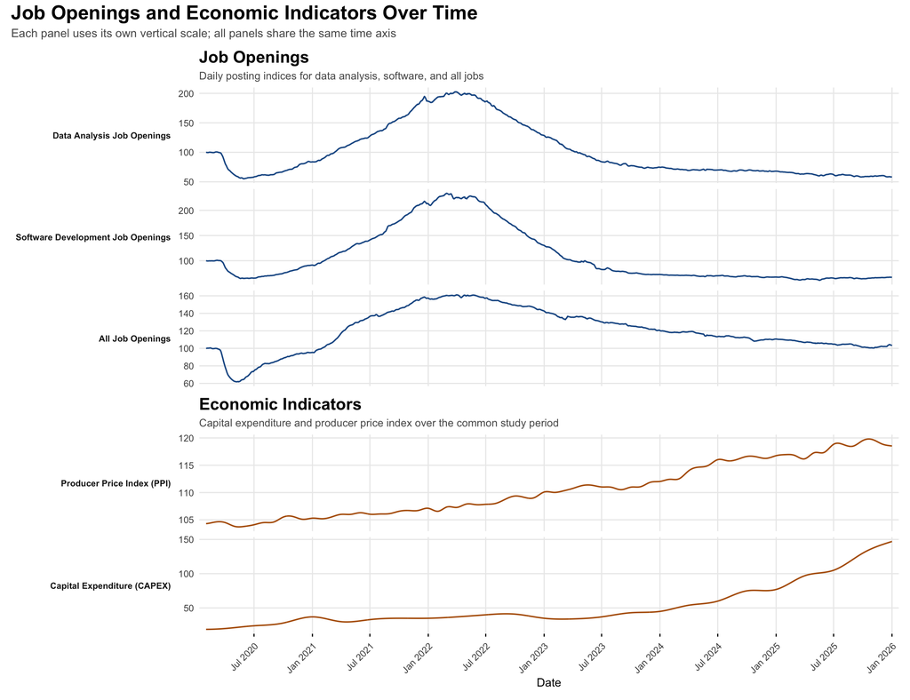

Figure 1. **Job openings, CAPEX and PPI over time.** Daily job-posting indices (top) above capital expenditure and the producer price index (bottom). Each panel has its own scale, so compare shapes rather than levels.

```r
economic_lookup <- tibble(
  Column = unname(capex_ppi_columns),
  Series = case_when(
    grepl("capex",   names(capex_ppi_columns), ignore.case = TRUE) ~ "Capital Expenditure (CAPEX)",
    grepl("PCU|PPI", names(capex_ppi_columns), ignore.case = TRUE) ~ "Producer Price Index (PPI)",
    TRUE ~ names(capex_ppi_columns)
  )
)

fig_jo_econ <- plot_jobs_with(
  economic_lookup,
  pred_title    = "Economic Indicators",
  pred_subtitle = "Capital expenditure and producer price index over the common study period",
  pred_color    = "#B45F06",
  figure_title  = "Job Openings and Economic Indicators Over Time"
)

fig_jo_econ
save_plot(fig_jo_econ, "EDA_Job_Openings_vs_CAPEX_PPI.png", height = 10)
```

### 4.1.2 Job openings and NVIDIA revenue

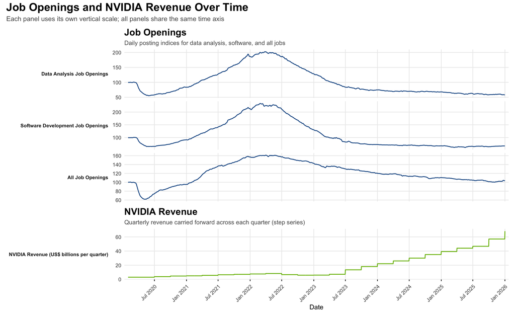

Figure 2. **Job openings and NVIDIA revenue over time.** Revenue is reported quarterly, so it appears as a staircase that steps up when each new quarter is reported.

```r
nvidia_lookup <- tibble(
  Column = unname(nvidia_columns),
  Series = "NVIDIA Revenue (US$ billions per quarter)"
)

fig_jo_nvidia <- plot_jobs_with(
  nvidia_lookup,
  pred_title    = "NVIDIA Revenue",
  pred_subtitle = "Quarterly revenue carried forward across each quarter (step series)",
  pred_color    = "#76B900",
  figure_title  = "Job Openings and NVIDIA Revenue Over Time"
)

fig_jo_nvidia
save_plot(fig_jo_nvidia, "EDA_Job_Openings_vs_NVIDIA.png", height = 8)
```

## 4.2 Linear regression

As a first look at explanatory power, each job-opening series is regressed on each predictor group separately (CAPEX and PPI; NVIDIA revenue; contemporaneous values, no time-series error structure). Because these are trending series, the R² values describe co-movement and should not be read as causal effects; residual autocorrelation is addressed in Parts 2 and 3.

```r
fit_models <- function(predictors) {
  lapply(job_columns, function(outcome) {
    model_formula <- as.formula(
      paste0("`", outcome, "` ~ ", paste0("`", unname(predictors), "`", collapse = " + "))
    )
    lm(model_formula, data = model_data)
  })
}

regression_models <- list(
  "CAPEX and PPI"  = fit_models(capex_ppi_columns),
  "NVIDIA Revenue" = fit_models(nvidia_columns)
)

regression_results <- imap_dfr(regression_models, function(models, group) {
  imap_dfr(models, function(model, job) {
    fit <- glance(model)
    tibble(
      Predictor_Group = group,
      Job_Openings    = job_labels[[job]],
      R_Squared       = fit$r.squared,
      Adj_R_Squared   = fit$adj.r.squared,
      RMSE            = sqrt(mean(residuals(model)^2)),
      AIC             = fit$AIC,
      N               = nobs(model)
    )
  })
})

save_table(regression_results, "Regression_Model_Summary.csv")

regression_results %>%
  kable(digits = 3) %>%
  kable_styling(full_width = FALSE, bootstrap_options = c("striped", "hover", "condensed")) %>%
  collapse_rows(columns = 1, valign = "top")
```

| Predictor_Group | Job_Openings | R_Squared | Adj_R_Squared | RMSE | AIC | N |
| --- | --- | --- | --- | --- | --- | --- |
| CAPEX and PPI | DA Job Openings | 0.226 | 0.226 | 39.316 | 22019.57 | 2162 |
|  | SW Job Openings | 0.244 | 0.243 | 46.105 | 22708.37 | 2162 |
|  | All Job Openings | 0.094 | 0.093 | 22.965 | 19694.79 | 2162 |
| NVIDIA Revenue | DA Job Openings | 0.278 | 0.277 | 37.992 | 21869.55 | 2162 |
|  | SW Job Openings | 0.265 | 0.264 | 45.461 | 22645.55 | 2162 |
|  | All Job Openings | 0.075 | 0.075 | 23.198 | 19736.45 | 2162 |

Table 6. **Simple regressions of job openings on each predictor group.** R-squared shows how much of the movement in job openings each group tracks. It describes co-movement, not cause, because these series trend over time.

**NoteFull regression summaries**

```r
for (group in names(regression_models)) {
  for (job in names(regression_models[[group]])) {
    cat("\n==========", group, "->", job_labels[[job]], "==========\n")
    print(summary(regression_models[[group]][[job]]))
  }
}
```

```
========== CAPEX and PPI -> DA Job Openings ==========

Call:
lm(formula = model_formula, data = model_data)

Residuals:
    Min      1Q  Median      3Q     Max
-74.798 -21.735  -7.198  17.198  87.581

Coefficients:
                                                Estimate Std. Error t value
(Intercept)                                    541.32396   39.39312  13.742
all_capex_ppi_daily_interpolated_PCUAINFOAINFO  -3.94749    0.38119 -10.356
all_capex_ppi_daily_interpolated_capex          -0.07661    0.06041  -1.268
                                               Pr(>|t|)
(Intercept)                                      <2e-16 ***
all_capex_ppi_daily_interpolated_PCUAINFOAINFO   <2e-16 ***
all_capex_ppi_daily_interpolated_capex            0.205
---
Signif. codes:  0 '***' 0.001 '**' 0.01 '*' 0.05 '.' 0.1 ' ' 1

Residual standard error: 39.34 on 2159 degrees of freedom
Multiple R-squared:  0.2263,    Adjusted R-squared:  0.2256
F-statistic: 315.8 on 2 and 2159 DF,  p-value: < 2.2e-16


========== CAPEX and PPI -> SW Job Openings ==========

Call:
lm(formula = model_formula, data = model_data)

Residuals:
    Min      1Q  Median      3Q     Max
-81.981 -25.299  -6.714  16.879 107.788

Coefficients:
                                                Estimate Std. Error t value
(Intercept)                                    803.42387   46.19571  17.392
all_capex_ppi_daily_interpolated_PCUAINFOAINFO  -6.37023    0.44702 -14.250
all_capex_ppi_daily_interpolated_capex           0.17856    0.07084   2.521
```

[output cut: 84 more lines]

```

Residuals:
    Min      1Q  Median      3Q     Max
-64.585  -4.009  -0.158  13.542  36.854

Coefficients:
                Estimate Std. Error t value Pr(>|t|)
(Intercept)    127.67654    0.73719  173.19   <2e-16 ***
NVIDIA_Revenue  -0.41272    0.03109  -13.27   <2e-16 ***
---
Signif. codes:  0 '***' 0.001 '**' 0.01 '*' 0.05 '.' 0.1 ' ' 1

Residual standard error: 23.21 on 2160 degrees of freedom
Multiple R-squared:  0.07542,   Adjusted R-squared:  0.075
F-statistic: 176.2 on 1 and 2160 DF,  p-value: < 2.2e-16
```

## 4.3 Cross-correlation analysis (CCF)

We use the CCF to examine lead–lag dependence between job openings and each external indicator (CAPEX, PPI, and NVIDIA revenue). The sample CCF at lag $k$ estimates $\text{cor}(\text{Job}_{t+k}, X_t)$, so:

- **positive lags** → the predictor *leads* job openings,
- **negative lags** → job openings lead the predictor,
- **lag 0** → same-day relationship.

Approximate 95% significance limits are $\pm 1.96/\sqrt{N}$.

**Important**

**CCF on raw levels can be misleading.** When two series are trending or nonstationary, they can appear strongly correlated at every lag simply because they share a trend. We therefore report the CCF on levels for completeness, and then on **first-differenced** series (daily changes), which is the more reliable basis for identifying lead–lag structure. Prewhitening is a further refinement.

```r
compute_ccf <- function(data, lag_max) {

  results <- list()

  for (job_name in names(job_columns)) {
    for (predictor_name in names(predictor_columns)) {

      pair <- data %>%
        select(job  = all_of(job_columns[[job_name]]),
               pred = all_of(predictor_columns[[predictor_name]])) %>%
        drop_na()

      if (nrow(pair) > lag_max + 2 && sd(pair$job) > 0 && sd(pair$pred) > 0) {

        cc <- ccf(pair$job, pair$pred, lag.max = lag_max, plot = FALSE)

        results[[length(results) + 1]] <- tibble(
          Category        = predictor_groups[[predictor_name]],
          Job_Openings    = job_name,
          Predictor       = predictor_name,
          Lag             = as.numeric(cc$lag),
          CCF             = as.numeric(cc$acf),
          N               = nrow(pair),
          Approx_95_Bound = 1.96 / sqrt(nrow(pair))
        )
      }
    }
  }

  bind_rows(results) %>%
    mutate(Significant = abs(CCF) > Approx_95_Bound)
}

label_ccf <- function(ccf_df) {
  ccf_df %>%
    mutate(
      Job_Type = factor(
        recode(Job_Openings, DA = "Data Analysis", SW = "Software Development",
               ALL = "All Job Openings"),
        levels = c("All Job Openings", "Data Analysis", "Software Development")
      ),
      Predictor_Label = case_when(
        grepl("PCU|PPI", Predictor, ignore.case = TRUE) ~ "PPI (Information)",
        grepl("CAPEX",   Predictor, ignore.case = TRUE) ~ "CAPEX",
        grepl("NVIDIA",  Predictor, ignore.case = TRUE) ~ "NVIDIA Revenue ($B)",
        TRUE ~ Predictor
      ),
      Category = factor(Category, levels = c("CAPEX and PPI", "NVIDIA Revenue"))
    )
}

# Strongest absolute CCF for each job x predictor pair
ccf_peaks <- function(ccf_df) {
  ccf_df %>%
    group_by(Category, Job_Type, Predictor_Label) %>%
    slice_max(abs(CCF), n = 1, with_ties = FALSE) %>%
    ungroup() %>%
    mutate(
      Lag_Interpretation = case_when(
        Lag > 0 ~ "Predictor leads job openings",
        Lag < 0 ~ "Job openings lead predictor",
        TRUE    ~ "Same-day relationship"
      )
    ) %>%
    arrange(Category, Job_Type, desc(abs(CCF))) %>%
    select(Category, Job_Type, Predictor = Predictor_Label, Lag, CCF,
           Approx_95_Bound, Significant, Lag_Interpretation)
}

# Heatmap of all CCF values
ccf_heatmap <- function(ccf_df, title, subtitle) {
  ggplot(ccf_df, aes(Lag, Predictor_Label, fill = CCF)) +
    geom_tile(color = "white", linewidth = 0.2) +
    geom_vline(xintercept = 0, color = "black", linewidth = 0.6) +
    facet_grid(Category ~ Job_Type, scales = "free_y", space = "free_y", switch = "y") +
    scale_fill_gradient2(low = "#3B4CC0", mid = "#F7F7F7", high = "#B40426",
                         midpoint = 0, limits = c(-1, 1), oob = squish,
                         breaks = seq(-1, 1, 0.5), name = "CCF") +
    scale_x_continuous(breaks = seq(-20, 20, 10), expand = c(0, 0)) +
    labs(title = title, subtitle = subtitle, x = "Lag in days", y = NULL,
         caption = paste0("Blue = negative, red = positive correlation. ",
                          "Positive lags indicate that the external indicator leads job openings.")) +
    theme_ts() +
    theme(panel.grid = element_blank(),
          strip.placement = "outside",
          strip.text.y.left = element_text(angle = 0, face = "bold"),
          axis.text.y = element_text(size = 8.5),
          legend.position = "right")
}

# Stem plots; significant lags are highlighted
ccf_stem_plot <- function(ccf_df, title, subtitle, facet = c("grid", "wrap")) {

  facet  <- match.arg(facet)
  bounds <- ccf_df %>% distinct(Job_Type, Predictor_Label, Approx_95_Bound)

  p <- ggplot(ccf_df, aes(Lag, CCF)) +
    geom_hline(yintercept = 0, linewidth = 0.4) +
    geom_hline(data = bounds, aes(yintercept =  Approx_95_Bound),
               linetype = "dashed", linewidth = 0.45, color = "steelblue") +
    geom_hline(data = bounds, aes(yintercept = -Approx_95_Bound),
               linetype = "dashed", linewidth = 0.45, color = "steelblue") +
    geom_segment(aes(xend = Lag, y = 0, yend = CCF, color = Significant), linewidth = 0.6) +
    geom_vline(xintercept = 0, linewidth = 0.5) +
    scale_color_manual(values = c(`TRUE` = "#3B4CC0", `FALSE` = "gray65"),
                       labels = c(`TRUE` = "Outside 95% limits", `FALSE` = "Within limits"),
                       name = NULL) +
    scale_x_continuous(breaks = seq(-lag_max, lag_max, 10)) +
    coord_cartesian(ylim = c(-1, 1)) +
    labs(title = title, subtitle = subtitle, x = "Lag in days",
         y = "Cross-correlation coefficient",
         caption = paste0("Dashed lines show approximate 95% limits. ",
                          "Positive lags indicate that the predictor leads job openings.")) +
    theme_ts()

  if (facet == "grid") {
    p + facet_grid(rows = vars(Job_Type), cols = vars(Predictor_Label))
  } else {
    p + facet_wrap(~ Predictor_Label, ncol = 3)
  }
}
```

### 4.3.1 CCF on levels

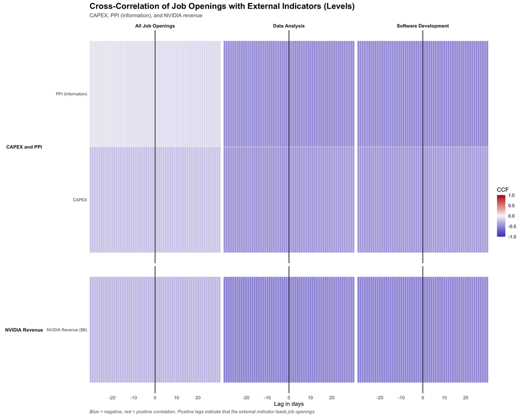

Figure 3. **Cross-correlation of job openings and predictors, in levels.** Each cell is the correlation at one lag (red positive, blue negative). Similar colors at every lag point to a shared trend rather than a true lead-lag link.

```r
ccf_levels <- compute_ccf(ccf_data, lag_max) %>% label_ccf()
save_table(ccf_levels, "CCF_levels_all_values.csv")

fig_ccf_levels_heat <- ccf_heatmap(
  ccf_levels,
  title    = "Cross-Correlation of Job Openings with External Indicators (Levels)",
  subtitle = "CAPEX, PPI (Information), and NVIDIA revenue"
)

fig_ccf_levels_heat
save_plot(fig_ccf_levels_heat, "CCF_levels_heatmap.png", width = 15, height = 12)
```

The near-uniform colour across lags in the levels heatmap is the signature of shared trends rather than a genuine lead–lag relationship, which motivates differencing.

### 4.3.2 CCF on first differences

```r
ccf_data_diff <- ccf_data %>%
  arrange(Date) %>%
  mutate(across(-Date, ~ .x - dplyr::lag(.x))) %>%
  slice(-1)

ccf_diff <- compute_ccf(ccf_data_diff, lag_max) %>% label_ccf()
save_table(ccf_diff, "CCF_first_difference_all_values.csv")
```

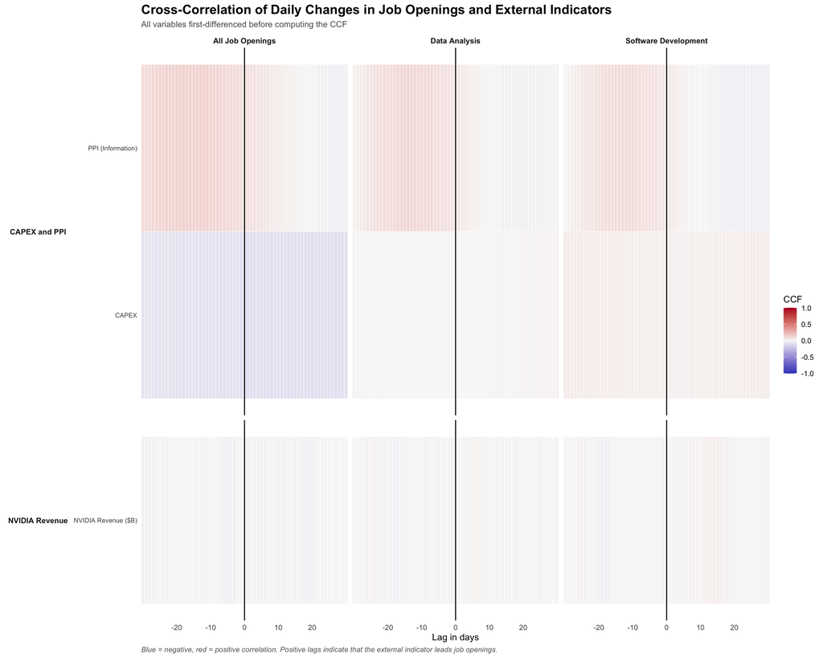

Figure 4. **Cross-correlation of daily changes.** The same heatmap after taking day-to-day changes, which removes shared trends and gives a more reliable view of which series moves first.

```r
fig_ccf_diff_heat <- ccf_heatmap(
  ccf_diff,
  title    = "Cross-Correlation of Daily Changes in Job Openings and External Indicators",
  subtitle = "All variables first-differenced before computing the CCF"
)

fig_ccf_diff_heat
save_plot(fig_ccf_diff_heat, "CCF_first_difference_heatmap.png", width = 15, height = 12)
```

#### 4.3.2.1 CAPEX and PPI

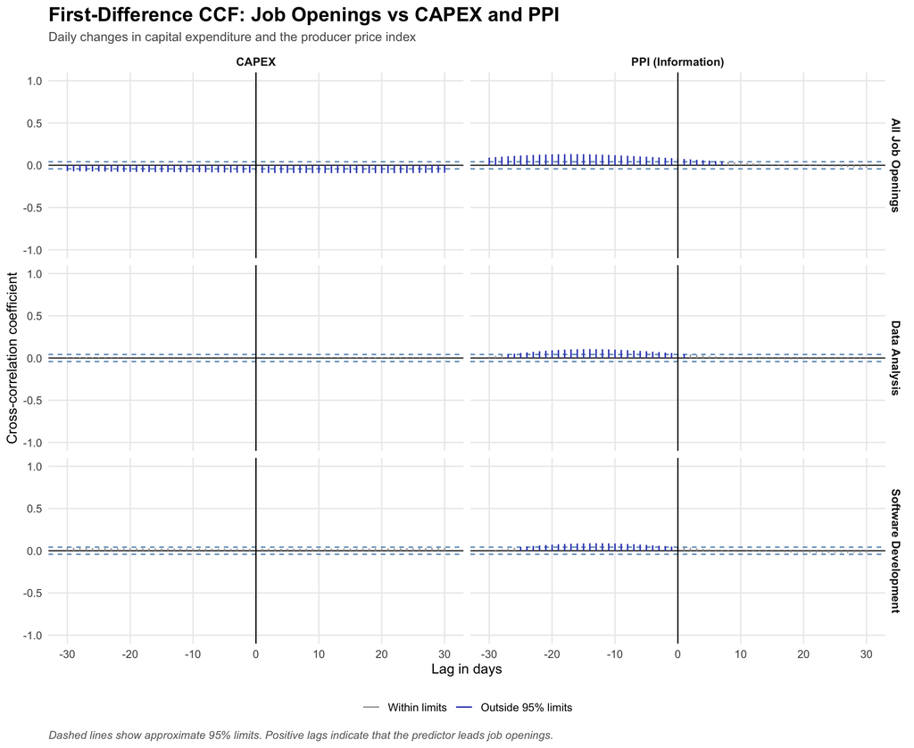

Figure 5. **Daily-change CCF: job openings vs CAPEX and PPI.** Bars outside the dashed 95% limits (dark blue) are statistically meaningful. Positive lags mean the predictor leads job openings.

```r
fig_ccf_diff_capex <- ccf_diff %>%
  filter(Category == "CAPEX and PPI") %>%
  ccf_stem_plot(
    title    = "First-Difference CCF: Job Openings vs CAPEX and PPI",
    subtitle = "Daily changes in capital expenditure and the producer price index"
  )

fig_ccf_diff_capex
save_plot(fig_ccf_diff_capex, "CCF_diff_Job_Openings_vs_CAPEX_PPI.png", width = 11)
```

#### 4.3.2.2 NVIDIA revenue

**Note**

NVIDIA revenue is a quarterly step series, so its *daily* change is zero on almost every day and jumps only when a new quarter begins (about four times a year). The first-difference CCF below is therefore based on very few non-zero changes and should be read with caution; the CCF on levels above mostly reflects shared trends.

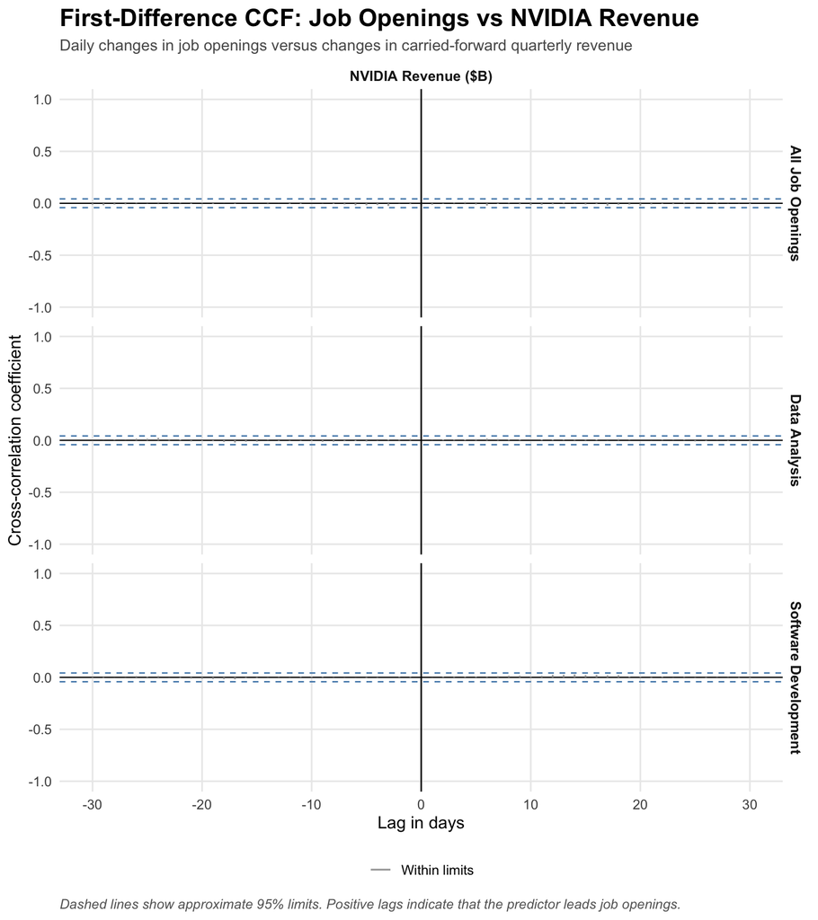

Figure 6. **Daily-change CCF: job openings vs NVIDIA revenue.** Revenue changes only a few times a year, so very few days carry any signal. Read these correlations with caution.

```r
fig_ccf_diff_nvidia <- ccf_diff %>%
  filter(Category == "NVIDIA Revenue") %>%
  ccf_stem_plot(
    title    = "First-Difference CCF: Job Openings vs NVIDIA Revenue",
    subtitle = "Daily changes in job openings versus changes in carried-forward quarterly revenue"
  )

fig_ccf_diff_nvidia
save_plot(fig_ccf_diff_nvidia, "CCF_diff_Job_Openings_vs_NVIDIA.png", width = 8)
```

#### 4.3.2.3 Strongest lead–lag relationships

```r
peak_levels <- ccf_peaks(ccf_levels)
peak_diff   <- ccf_peaks(ccf_diff)

save_table(peak_levels, "CCF_levels_peak_values.csv")
save_table(peak_diff,   "CCF_first_difference_peak_values.csv")

peak_diff %>%
  kable(digits = 3) %>%
  kable_styling(full_width = FALSE, bootstrap_options = c("striped", "hover", "condensed")) %>%
  collapse_rows(columns = 1:2, valign = "top") %>%
  scroll_box(height = "500px")
```

| Category | Job_Type | Predictor | Lag | CCF | Approx_95_Bound | Significant | Lag_Interpretation |
| --- | --- | --- | --- | --- | --- | --- | --- |
| CAPEX and PPI | All Job Openings | PPI (Information) | -17 | 0.132 | 0.042 | TRUE | Job openings lead predictor |
|  |  | CAPEX | 19 | -0.093 | 0.042 | TRUE | Predictor leads job openings |
|  | Data Analysis | PPI (Information) | -14 | 0.106 | 0.042 | TRUE | Job openings lead predictor |
|  |  | CAPEX | 30 | 0.015 | 0.042 | FALSE | Predictor leads job openings |
|  | Software Development | PPI (Information) | -13 | 0.089 | 0.042 | TRUE | Job openings lead predictor |
|  |  | CAPEX | -30 | 0.035 | 0.042 | FALSE | Job openings lead predictor |
| NVIDIA Revenue | All Job Openings | NVIDIA Revenue ($B) | -3 | -0.025 | 0.042 | FALSE | Job openings lead predictor |
|  | Data Analysis | NVIDIA Revenue ($B) | -24 | 0.023 | 0.042 | FALSE | Job openings lead predictor |
|  | Software Development | NVIDIA Revenue ($B) | 14 | 0.028 | 0.042 | FALSE | Predictor leads job openings |

Table 7. **Strongest lead-lag relationship for each pair.** For every job series and predictor, the lag where the correlation of daily changes is largest. A positive lag means the predictor moves first, and Significant marks values outside the 95% limits.

# 5 Part 2 – Forecasting Job Openings (Daily)

## 5.1 Design

The final 36 days are held out as a test period. Every model is fitted on the training period only and then used to predict the test period.

| Model | Predictors | Purpose |
| --- | --- | --- |
| Univariate ARIMA (`auto.arima`) | None (own history) | Baseline |
| Prophet | None (trend + weekly/yearly seasonality) | Baseline |
| Regression + ARIMA errors | CAPEX + PPI | External signal |
| Regression + ARIMA errors | NVIDIA revenue | External signal |

Table 8. **Forecasting models compared.** Two baselines that use only a job series’ own history, and ARIMAX models that add one group of outside predictors.

Daily series are modelled with weekly seasonality (`frequency = 7`). The regression-with-ARIMA-error models use the **observed** predictor values in the test period (ex-post forecasts), so they measure how much the predictors explain out of sample rather than a fully operational forecast.

```r
# Fit on the training window and predict the test window.
# Returns the model plus fitted (training) and predicted (test) values.
fit_and_forecast <- function(y, xreg = NULL, h = test_horizon) {

  n         <- length(y)
  train_end <- n - h
  y_train   <- ts(y[1:train_end], frequency = 7)

  if (is.null(xreg)) {
    model <- auto.arima(y_train, seasonal = TRUE,
                        stepwise = !exhaustive_search, approximation = !exhaustive_search)
    fc <- forecast(model, h = h, level = 95)
  } else {
    xreg <- as.matrix(xreg)
    storage.mode(xreg) <- "double"
    model <- auto.arima(y_train, xreg = xreg[1:train_end, , drop = FALSE],
                        seasonal = TRUE, stepwise = !exhaustive_search, approximation = !exhaustive_search)
    fc <- forecast(model, xreg = xreg[(train_end + 1):n, , drop = FALSE], level = 95)
  }

  list(
    model = model,
    results = tibble(
      Actual           = y,
      Fitted_Predicted = c(as.numeric(fitted(model)), as.numeric(fc$mean)),
      Lower_95         = c(rep(NA_real_, train_end), as.numeric(fc$lower[, 1])),
      Upper_95         = c(rep(NA_real_, train_end), as.numeric(fc$upper[, 1])),
      Period           = rep(c("Training", "Test"), c(train_end, h))
    )
  )
}

# Actual vs predicted plot: test period only, or the whole series
plot_actual_vs_predicted <- function(pred_df, title, subtitle, whole = FALSE) {

  pred_name  <- if (whole) "Fitted / Predicted" else "Predicted"
  test_start <- min(pred_df$Date[pred_df$Period == "Test"])
  df         <- if (whole) pred_df else filter(pred_df, Period == "Test")

  long_df <- df %>%
    select(Date, Job_Type, Actual, Fitted_Predicted) %>%
    pivot_longer(c(Actual, Fitted_Predicted), names_to = "Series", values_to = "Value") %>%
    mutate(Series = if_else(Series == "Actual", "Actual", pred_name))

  p <- ggplot(df, aes(x = Date))

  if (!whole) {
    p <- p + geom_ribbon(aes(ymin = Lower_95, ymax = Upper_95),
                         fill = "gray70", alpha = 0.35)
  } else {
    p <- p + geom_vline(xintercept = test_start, color = "gray40",
                        linetype = "dotted", linewidth = 0.7)
  }

  p +
    geom_line(data = long_df, aes(y = Value, color = Series, linetype = Series),
              linewidth = if (whole) 0.6 else 0.9) +
    facet_grid(Job_Type ~ ., scales = "free_y") +
    scale_color_manual(values = setNames(c(col_actual, col_pred), c("Actual", pred_name))) +
    scale_linetype_manual(values = setNames(c("solid", "dashed"), c("Actual", pred_name))) +
    labs(
      title = title, subtitle = subtitle,
      x = "Date", y = "Job-posting index", color = NULL, linetype = NULL,
      caption = if (whole) {
        "Dashed line: fitted values (training) and predictions (test). Dotted vertical line marks the start of the test period."
      } else {
        paste0("The final ", test_horizon, " days were used as the test period. Shaded regions are 95% prediction intervals.")
      }
    ) +
    theme_ts()
}
```

## 5.2 Baseline models (job openings only)

### 5.2.1 Univariate ARIMA: future forecasts

Separate `auto.arima` models are fitted to the full history of each series to show the next 36 days.

```
$DA
Series: ts(model_data[[column_name]], frequency = 7)
ARIMA(0,2,1)(1,0,2)[7]

Coefficients:
          ma1     sar1    sma1     sma2
      -0.3954  -0.9223  0.0093  -0.8259
s.e.   0.0220   0.3248  0.3430   0.3139

sigma^2 = 0.01951:  log likelihood = 1011.48
AIC=-2012.95   AICc=-2012.92   BIC=-1985.34

$SW
Series: ts(model_data[[column_name]], frequency = 7)
ARIMA(0,2,2)(1,0,2)[7]

Coefficients:
          ma1     ma2     sar1     sma1     sma2
      -0.3765  0.0538  -0.9012  -0.0321  -0.8066
s.e.   0.0233  0.0223   0.1454   0.1565   0.1453

sigma^2 = 0.02162:  log likelihood = 916.93
AIC=-1821.86   AICc=-1821.81   BIC=-1788.72

$ALL
Series: ts(model_data[[column_name]], frequency = 7)
ARIMA(1,2,1)(0,0,1)[7]

Coefficients:
         ar1      ma1     sma1
      0.1721  -0.5675  -0.9037
s.e.  0.0518   0.0432   0.0104

sigma^2 = 0.006823:  log likelihood = 1982.97
AIC=-3957.94   AICc=-3957.92   BIC=-3935.85
```

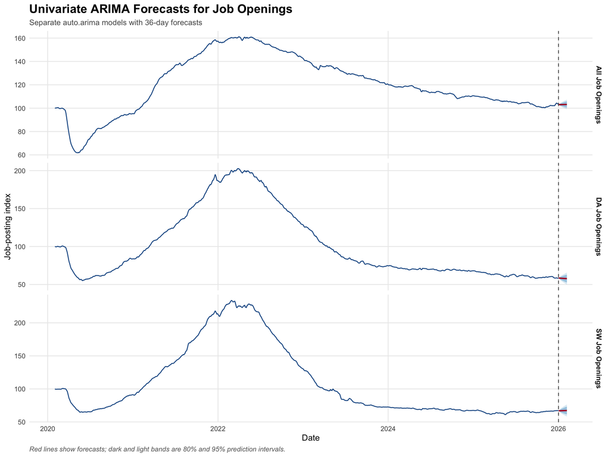

Figure 7. **Univariate ARIMA forecasts.** Each job series is projected forward from its own history alone. The red line is the forecast, and the shaded bands are 80% and 95% prediction intervals.

```r
arima_full_models <- cached("arima_full_models", lapply(job_columns, function(column_name) {
  auto.arima(ts(model_data[[column_name]], frequency = 7),
             seasonal = TRUE, stepwise = !exhaustive_search, approximation = !exhaustive_search)
}))

future_dates <- seq(max(model_data$Date) + 1, by = "day", length.out = forecast_horizon)

arima_future <- imap_dfr(arima_full_models, function(model, job) {
  fc <- forecast(model, h = forecast_horizon, level = c(80, 95))
  tibble(
    Date = future_dates, Forecast = as.numeric(fc$mean),
    Lower_80 = as.numeric(fc$lower[, "80%"]), Upper_80 = as.numeric(fc$upper[, "80%"]),
    Lower_95 = as.numeric(fc$lower[, "95%"]), Upper_95 = as.numeric(fc$upper[, "95%"]),
    Job_Type = job_labels[[job]]
  )
}) %>%
  mutate(Job_Type = factor(Job_Type, levels = job_levels))

arima_history <- imap_dfr(job_columns, function(column_name, job) {
  tibble(Date = model_data$Date, Value = model_data[[column_name]],
         Job_Type = job_labels[[job]])
}) %>%
  mutate(Job_Type = factor(Job_Type, levels = job_levels))

fig_arima_future <- ggplot() +
  geom_line(data = arima_history, aes(Date, Value), linewidth = 0.6, color = col_actual) +
  geom_ribbon(data = arima_future, aes(Date, ymin = Lower_95, ymax = Upper_95),
              fill = "#9ECAE1", alpha = 0.35) +
  geom_ribbon(data = arima_future, aes(Date, ymin = Lower_80, ymax = Upper_80),
              fill = "#4292C6", alpha = 0.40) +
  geom_line(data = arima_future, aes(Date, Forecast), linewidth = 0.9, color = col_pred) +
  geom_vline(xintercept = max(model_data$Date), linetype = "dashed", color = "gray35") +
  facet_grid(Job_Type ~ ., scales = "free_y") +
  labs(title = "Univariate ARIMA Forecasts for Job Openings",
       subtitle = paste0("Separate auto.arima models with ", forecast_horizon, "-day forecasts"),
       x = "Date", y = "Job-posting index",
       caption = "Red lines show forecasts; dark and light bands are 80% and 95% prediction intervals.") +
  theme_ts()

fig_arima_future
save_plot(fig_arima_future, "ARIMA_future_forecasts.png", width = 12)

arima_full_models
```

### 5.2.2 Fit all test-period models

```r
predictor_sets <- list(
  "ARIMA (baseline)"       = NULL,
  "ARIMAX: CAPEX + PPI"    = capex_ppi_columns,
  "ARIMAX: NVIDIA Revenue" = nvidia_columns
)

forecast_runs <- cached("forecast_runs", local({

forecast_runs <- list()

for (set_name in names(predictor_sets)) {

  forecast_runs[[set_name]] <- list()
  xcols <- predictor_sets[[set_name]]

  for (job_name in names(job_columns)) {

    run <- fit_and_forecast(
      y    = model_data[[job_columns[[job_name]]]],
      xreg = if (is.null(xcols)) NULL else model_data[, unname(xcols)]
    )

    run$results <- run$results %>%
      mutate(Date = model_data$Date, Model = set_name,
             Job_Type = job_labels[[job_name]], .before = 1)

    forecast_runs[[set_name]][[job_name]] <- run
  }
}

forecast_runs
}))

# ------------------------------------------------------------
# Prophet baseline (training data only)
# ------------------------------------------------------------

prophet_results <- cached("prophet_results", local({

prophet_results <- list()

for (job_name in names(job_columns)) {

  series_data <- tibble(ds = model_data$Date,
                        y  = model_data[[job_columns[[job_name]]]])

  train_end  <- nrow(series_data) - test_horizon
  train_data <- series_data[1:train_end, ]

  model <- prophet(train_data,
                   daily.seasonality = FALSE, weekly.seasonality = TRUE,
                   yearly.seasonality = TRUE, interval.width = 0.95)

  pred <- predict(model, series_data %>% select(ds))

  prophet_results[[job_name]] <- tibble(
    Date             = series_data$ds,
    Model            = "Prophet (baseline)",
    Job_Type         = job_labels[[job_name]],
    Actual           = series_data$y,
    Fitted_Predicted = pred$yhat,
    Lower_95         = if_else(seq_len(nrow(series_data)) > train_end, pred$yhat_lower, NA_real_),
    Upper_95         = if_else(seq_len(nrow(series_data)) > train_end, pred$yhat_upper, NA_real_),
    Period           = rep(c("Training", "Test"), c(train_end, test_horizon))
  )
}

prophet_results
}))

# ------------------------------------------------------------
# All predictions in one table
# ------------------------------------------------------------

model_order <- c("ARIMA (baseline)", "Prophet (baseline)", "ARIMAX: CAPEX + PPI",
                 "ARIMAX: NVIDIA Revenue")

all_predictions <- bind_rows(
  map_dfr(forecast_runs, ~ map_dfr(.x, "results")),
  bind_rows(prophet_results)
) %>%
  mutate(Job_Type = factor(Job_Type, levels = job_levels),
         Model    = factor(Model, levels = model_order))

save_table(all_predictions, "All_model_predictions.csv")

get_predictions <- function(model_name) filter(all_predictions, Model == model_name)
```

### 5.2.3 Univariate ARIMA: actual vs predicted

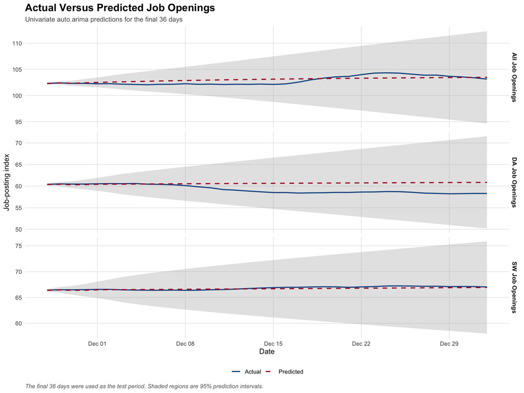

Figure 8. **ARIMA baseline on the test days.** Predicted versus actual job openings over the held-out final days, with a 95% prediction band. The closer the lines, the better the forecast.

```r
fig <- plot_actual_vs_predicted(
  get_predictions("ARIMA (baseline)"),
  title = "Actual Versus Predicted Job Openings",
  subtitle = paste0("Univariate auto.arima predictions for the final ", test_horizon, " days")
)
fig
save_plot(fig, "ARIMA_baseline_actual_vs_predicted.png", width = 12)
```

### 5.2.4 Prophet: actual vs predicted

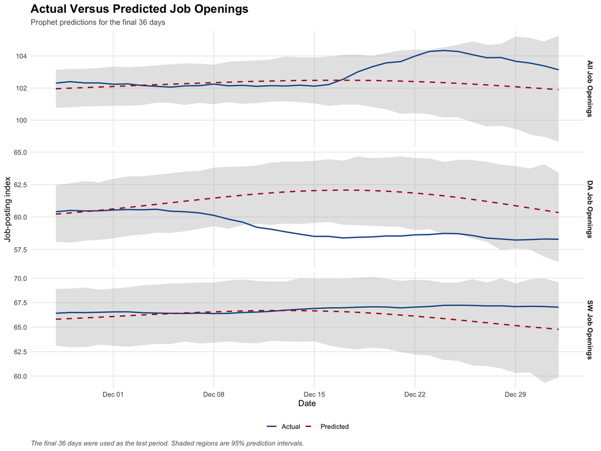

Figure 9. **Prophet baseline on the test days.** The same comparison using Prophet, which fits a smooth trend plus weekly and yearly patterns.

```r
fig <- plot_actual_vs_predicted(
  get_predictions("Prophet (baseline)"),
  title = "Actual Versus Predicted Job Openings",
  subtitle = paste0("Prophet predictions for the final ", test_horizon, " days")
)
fig
save_plot(fig, "Prophet_baseline_actual_vs_predicted.png", width = 12)
```

## 5.3 Regression with ARIMA errors (ARIMAX)

The model for each job-opening series is

$$y_t = \beta_0 + \boldsymbol{\beta}^\top \mathbf{x}_t + n_t, \qquad n_t \sim \text{(S)ARIMA}(p,d,q)(P,D,Q)_7,$$

where $\mathbf{x}_t$ contains one group of external predictors (CAPEX and PPI, or NVIDIA revenue) and the ARIMA orders for the error process are chosen by `auto.arima`.

### 5.3.1 Job openings vs. CAPEX + PPI

**Test period**

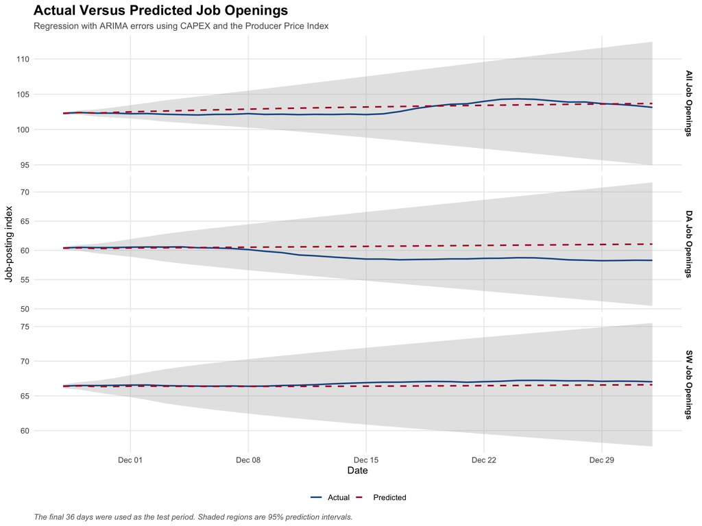

Figure 10. **ARIMAX with CAPEX and PPI, test period.** Forecasts from a regression with ARIMA errors that uses CAPEX and PPI as outside clues, compared with the actual values.

```r
fig <- plot_actual_vs_predicted(
  get_predictions("ARIMAX: CAPEX + PPI"),
  title = "Actual Versus Predicted Job Openings",
  subtitle = "Regression with ARIMA errors using CAPEX and the Producer Price Index"
)
fig
save_plot(fig, "ARIMAX_CAPEX_PPI_test_actual_vs_predicted.png", width = 12)
```

**Whole series**

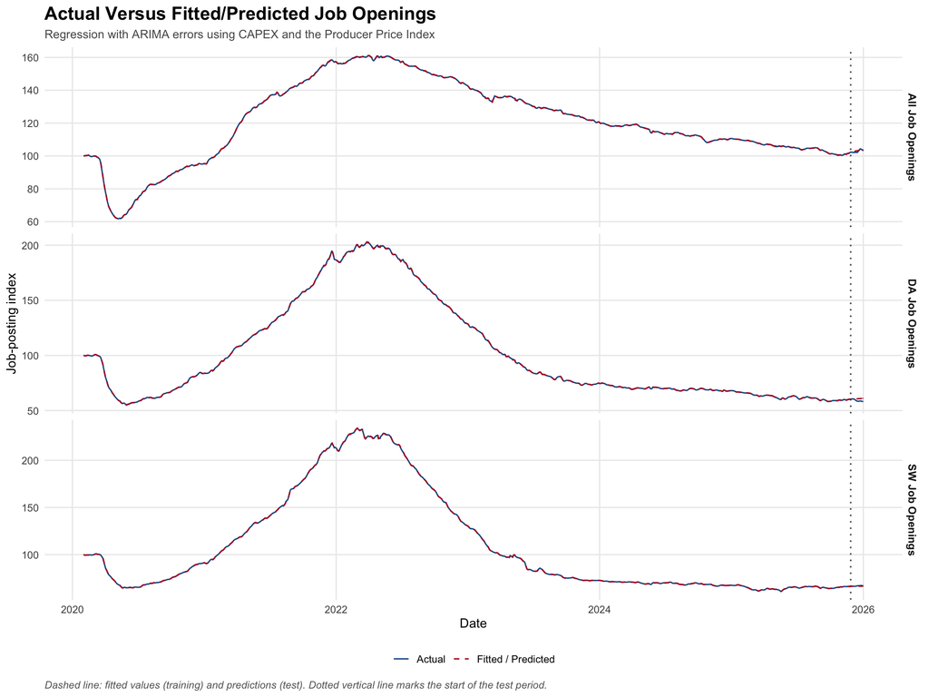

Figure 11. **ARIMAX with CAPEX and PPI, whole series.** Fitted values over the training period and predictions over the test period (to the right of the dotted line).

```r
fig <- plot_actual_vs_predicted(
  get_predictions("ARIMAX: CAPEX + PPI"),
  title = "Actual Versus Fitted/Predicted Job Openings",
  subtitle = "Regression with ARIMA errors using CAPEX and the Producer Price Index",
  whole = TRUE
)
fig
save_plot(fig, "ARIMAX_CAPEX_PPI_whole_actual_vs_predicted.png", width = 12)
```

### 5.3.2 Job openings vs. NVIDIA revenue

**Test period**

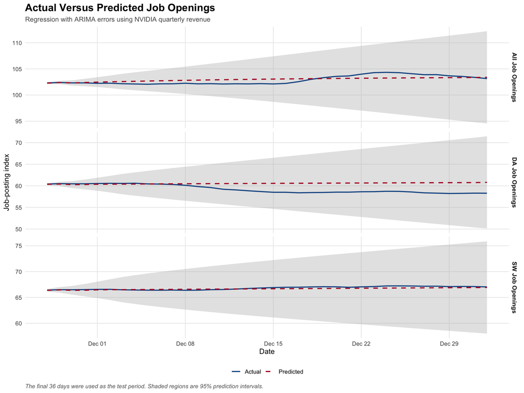

Figure 12. **ARIMAX with NVIDIA revenue, test period.** Forecasts from a regression with ARIMA errors that uses NVIDIA revenue as the outside clue, compared with the actual values.

```r
fig <- plot_actual_vs_predicted(
  get_predictions("ARIMAX: NVIDIA Revenue"),
  title = "Actual Versus Predicted Job Openings",
  subtitle = "Regression with ARIMA errors using NVIDIA quarterly revenue"
)
fig
save_plot(fig, "ARIMAX_NVIDIA_test_actual_vs_predicted.png", width = 12)
```

**Whole series**

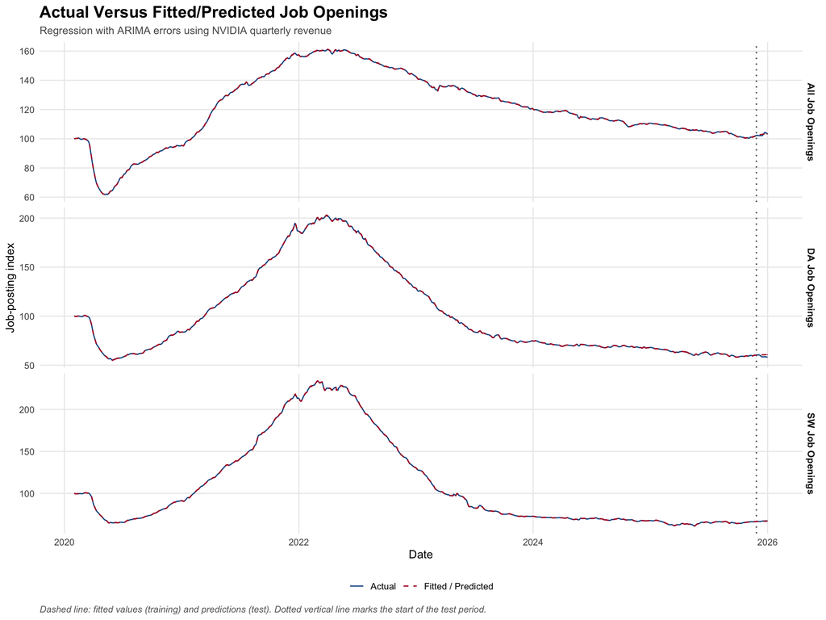

Figure 13. **ARIMAX with NVIDIA revenue, whole series.** Fitted values over the training period and predictions over the test period (to the right of the dotted line).

```r
fig <- plot_actual_vs_predicted(
  get_predictions("ARIMAX: NVIDIA Revenue"),
  title = "Actual Versus Fitted/Predicted Job Openings",
  subtitle = "Regression with ARIMA errors using NVIDIA quarterly revenue",
  whole = TRUE
)
fig
save_plot(fig, "ARIMAX_NVIDIA_whole_actual_vs_predicted.png", width = 12)
```

### 5.3.3 Selected models

```r
extract_model_description <- function(model) {
  output <- capture.output(print(model))
  trimws(output[grepl("Regression with ARIMA|ARIMA\\(", output)][1])
}

selected_models <- imap_dfr(forecast_runs, function(runs, set_name) {
  imap_dfr(runs, function(run, job_name) {
    tibble(
      Model          = set_name,
      Job_Openings   = job_labels[[job_name]],
      Selected_Model = extract_model_description(run$model),
      AICc           = run$model$aicc
    )
  })
}) %>%
  mutate(Job_Openings = factor(Job_Openings, levels = job_levels)) %>%
  arrange(factor(Model, levels = model_order), Job_Openings)

save_table(selected_models, "Selected_ARIMA_models.csv")

selected_models %>%
  kable(digits = 1,
        col.names = c("Model", "Job Openings", "Selected Model", "AICc")) %>%
  kable_styling(full_width = FALSE, bootstrap_options = c("striped", "condensed")) %>%
  collapse_rows(columns = 1, valign = "top")
```

| Model | Job Openings | Selected Model | AICc |
| --- | --- | --- | --- |
| ARIMA (baseline) | All Job Openings | ARIMA(2,2,3)(2,0,1)[7] | -4436.3 |
|  | DA Job Openings | ARIMA(2,2,2)(1,0,1)[7] | -2373.3 |
|  | SW Job Openings | ARIMA(0,2,1)(0,0,1)[7] | -2213.9 |
| ARIMAX: CAPEX + PPI | All Job Openings | Regression with ARIMA(2,2,3)(2,0,1)[7] errors | -4433.2 |
|  | DA Job Openings | Regression with ARIMA(2,2,2)(1,0,1)[7] errors | -2370.6 |
|  | SW Job Openings | Regression with ARIMA(0,2,1)(0,0,1)[7] errors | -2213.4 |
| ARIMAX: NVIDIA Revenue | All Job Openings | Regression with ARIMA(2,2,3)(2,0,1)[7] errors | -4435.6 |
|  | DA Job Openings | Regression with ARIMA(2,2,2)(1,0,1)[7] errors | -2372.5 |
|  | SW Job Openings | Regression with ARIMA(0,2,1)(0,0,1)[7] errors | -2211.9 |

Table 9. **Models chosen by auto.arima.** The error structure each forecasting model settled on for every job series, with AICc as the fit score (lower is better).

**NoteFull model summaries (coefficients and training accuracy)**

```r
for (set_name in names(forecast_runs)) {
  for (job_name in names(forecast_runs[[set_name]])) {
    cat("\n==========", set_name, "->", job_labels[[job_name]], "==========\n")
    print(summary(forecast_runs[[set_name]][[job_name]]$model))
  }
}
```

```
========== ARIMA (baseline) -> DA Job Openings ==========
Series: y_train
ARIMA(2,2,2)(1,0,1)[7]

Coefficients:
         ar1      ar2      ma1     ma2     sar1     sma1
      1.0148  -0.0510  -1.3638  0.4057  -0.0169  -0.9114
s.e.  0.0651   0.0668   0.0604  0.0620   0.0255   0.0113

sigma^2 = 0.01898:  log likelihood = 1193.68
AIC=-2373.36   AICc=-2373.3   BIC=-2333.73

Training set error measures:
                       ME      RMSE        MAE         MPE       MAPE
Training set 0.0004257048 0.1375202 0.08923232 0.003969088 0.08899121
                   MASE          ACF1
Training set 0.06461492 -0.0002245539

========== ARIMA (baseline) -> SW Job Openings ==========
Series: y_train
ARIMA(0,2,1)(0,0,1)[7]

Coefficients:
          ma1     sma1
      -0.3300  -0.9073
s.e.   0.0195   0.0094

sigma^2 = 0.0205:  log likelihood = 1109.95
AIC=-2213.9   AICc=-2213.89   BIC=-2196.92

Training set error measures:
                      ME      RMSE        MAE         MPE       MAPE       MASE
Training set 0.001045314 0.1430392 0.08433247 0.006006905 0.07758386 0.05555588
                    ACF1
Training set -0.02230147

========== ARIMA (baseline) -> All Job Openings ==========
Series: y_train
ARIMA(2,2,3)(2,0,1)[7]

```

[output cut: 124 more lines]

```
         ar1      ar2      ma1     ma2      ma3     sar1    sar2     sma1
      1.5361  -0.5630  -1.8512  1.0251  -0.1315  -0.0018  0.0254  -0.9204
s.e.  0.1204   0.1153   0.1233  0.1704   0.0575   0.0268  0.0251   0.0107
      NVIDIA_Revenue
              0.0019
s.e.          0.0017

sigma^2 = 0.007186:  log likelihood = 2227.84
AIC=-4435.68   AICc=-4435.58   BIC=-4379.07

Training set error measures:
                       ME       RMSE       MAE         MPE       MAPE
Training set 0.0003030989 0.08454899 0.0581836 0.001555971 0.05013969
                   MASE         ACF1
Training set 0.07148177 -0.002503328
```

## 5.4 Model comparison

### 5.4.1 Test-period accuracy

```r
accuracy_table <- all_predictions %>%
  filter(Period == "Test") %>%
  group_by(Job_Type, Model) %>%
  summarise(
    RMSE = sqrt(mean((Actual - Fitted_Predicted)^2, na.rm = TRUE)),
    MAE  = mean(abs(Actual - Fitted_Predicted), na.rm = TRUE),
    MAPE = mean(if_else(Actual != 0, abs((Actual - Fitted_Predicted) / Actual), NA_real_),
                na.rm = TRUE) * 100,
    .groups = "drop"
  ) %>%
  group_by(Job_Type) %>%
  mutate(
    RMSE_vs_ARIMA = 100 * (RMSE / RMSE[Model == "ARIMA (baseline)"] - 1),
    Best          = RMSE == min(RMSE)
  ) %>%
  ungroup() %>%
  arrange(Job_Type, Model)

save_table(accuracy_table, "Test_accuracy_all_models.csv")

accuracy_table %>%
  select(-Best) %>%
  kable(digits = 3,
        col.names = c("Job Openings", "Model", "RMSE", "MAE", "MAPE (%)",
                      "RMSE change vs ARIMA (%)")) %>%
  kable_styling(full_width = FALSE, bootstrap_options = c("striped", "hover", "condensed")) %>%
  row_spec(which(accuracy_table$Best), bold = TRUE, background = "#FFF3B0") %>%
  collapse_rows(columns = 1, valign = "top")
```

| Job Openings | Model | RMSE | MAE | MAPE (%) | RMSE change vs ARIMA (%) |
| --- | --- | --- | --- | --- | --- |
| All Job Openings | ARIMA (baseline) | 0.618 | 0.528 | 0.514 | 0.000 |
|  | Prophet (baseline) | 1.011 | 0.746 | 0.720 | 63.414 |
|  | ARIMAX: CAPEX + PPI | 0.612 | 0.515 | 0.502 | -1.004 |
|  | ARIMAX: NVIDIA Revenue | 0.615 | 0.527 | 0.512 | -0.524 |
| DA Job Openings | ARIMA (baseline) | 1.733 | 1.422 | 2.427 | 0.000 |
|  | Prophet (baseline) | 2.449 | 2.091 | 3.560 | 41.273 |
|  | ARIMAX: CAPEX + PPI | 1.814 | 1.483 | 2.530 | 4.681 |
|  | ARIMAX: NVIDIA Revenue | 1.668 | 1.371 | 2.339 | -3.775 |
| SW Job Openings | ARIMA (baseline) | 0.215 | 0.186 | 0.279 | 0.000 |
|  | Prophet (baseline) | 1.019 | 0.745 | 1.111 | 374.585 |
|  | ARIMAX: CAPEX + PPI | 0.435 | 0.357 | 0.533 | 102.621 |
|  | ARIMAX: NVIDIA Revenue | 0.222 | 0.191 | 0.286 | 3.142 |

Table 10. **Accuracy on the held-out test days.** RMSE, MAE and MAPE measure forecast error (lower is better). The last column compares each model with the ARIMA baseline, and bold rows mark the best model for each job series.

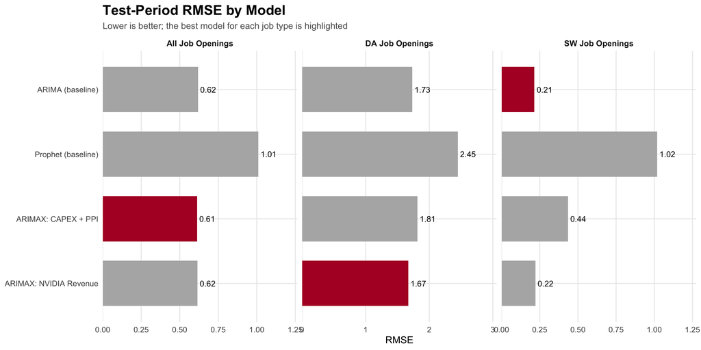

Figure 14. **Test-period error by model.** RMSE for every model and job series. Shorter bars are better, and the best model in each panel is highlighted.

```r
fig_accuracy <- accuracy_table %>%
  mutate(Model = fct_rev(Model)) %>%
  ggplot(aes(RMSE, Model, fill = Best)) +
  geom_col(width = 0.7) +
  geom_text(aes(label = number(RMSE, accuracy = 0.01)), hjust = -0.15, size = 3.5) +
  facet_wrap(~ Job_Type, scales = "free_x") +
  scale_fill_manual(values = c(`TRUE` = col_pred, `FALSE` = "gray70"), guide = "none") +
  scale_x_continuous(expand = expansion(mult = c(0, 0.25))) +
  labs(title = "Test-Period RMSE by Model",
       subtitle = "Lower is better; the best model for each job type is highlighted",
       x = "RMSE", y = NULL) +
  theme_ts()

fig_accuracy
save_plot(fig_accuracy, "Test_RMSE_by_model.png", width = 12, height = 6)
```

```r
best_models <- accuracy_table %>%
  filter(Best) %>%
  select(Job_Type, Best_Model = Model, RMSE, RMSE_vs_ARIMA)

best_models %>%
  kable(digits = 3,
        col.names = c("Job Openings", "Best Model", "RMSE", "RMSE change vs ARIMA (%)")) %>%
  kable_styling(full_width = FALSE)
```

| Job Openings | Best Model | RMSE | RMSE change vs ARIMA (%) |
| --- | --- | --- | --- |
| All Job Openings | ARIMAX: CAPEX + PPI | 0.612 | -1.004 |
| DA Job Openings | ARIMAX: NVIDIA Revenue | 1.668 | -3.775 |
| SW Job Openings | ARIMA (baseline) | 0.215 | 0.000 |

Table 11. **Best model for each job series.** The model with the lowest test-period RMSE, and how far its error sits above or below the ARIMA baseline.

### 5.4.2 Diebold–Mariano tests against the ARIMA baseline

The Diebold–Mariano (DM) test checks whether the squared-error loss of each external-predictor model differs significantly from the univariate ARIMA baseline over the test period. Because all test forecasts come from a single forecast origin (horizons 1 to 36), the test is used here as a descriptive guide rather than a formal multi-origin comparison.

```r
baseline_errors <- all_predictions %>%
  filter(Period == "Test", Model == "ARIMA (baseline)") %>%
  transmute(Date, Job_Type, Baseline_Error = Actual - Fitted_Predicted)

dm_results <- all_predictions %>%
  filter(Period == "Test", Model != "ARIMA (baseline)") %>%
  transmute(Date, Job_Type, Model, Model_Error = Actual - Fitted_Predicted) %>%
  inner_join(baseline_errors, by = c("Date", "Job_Type")) %>%
  group_by(Job_Type, Model) %>%
  summarise(
    {
      dm <- forecast::dm.test(Baseline_Error, Model_Error,
                              alternative = "two.sided", h = 1, power = 2)
      tibble(DM_Statistic = unname(dm$statistic), P_Value = dm$p.value)
    },
    Lower_Loss = if_else(mean(Model_Error^2) < mean(Baseline_Error^2),
                         as.character(first(Model)), "ARIMA (baseline)"),
    .groups = "drop"
  ) %>%
  mutate(Significant = if_else(P_Value < 0.05, "Yes", "No"))

save_table(dm_results, "Diebold_Mariano_vs_ARIMA.csv")

dm_results %>%
  kable(digits = 3,
        col.names = c("Job Openings", "Model", "DM Statistic", "p-value",
                      "Lower-Loss Model", "Significant (5%)")) %>%
  kable_styling(full_width = FALSE, bootstrap_options = c("striped", "condensed")) %>%
  collapse_rows(columns = 1, valign = "top")
```

| Job Openings | Model | DM Statistic | p-value | Lower-Loss Model | Significant (5%) |
| --- | --- | --- | --- | --- | --- |
| All Job Openings | Prophet (baseline) | -2.811 | 0.008 | ARIMA (baseline) | Yes |
|  | ARIMAX: CAPEX + PPI | 0.410 | 0.684 | ARIMAX: CAPEX + PPI | No |
|  | ARIMAX: NVIDIA Revenue | 0.246 | 0.807 | ARIMAX: NVIDIA Revenue | No |
| DA Job Openings | Prophet (baseline) | -5.495 | 0.000 | ARIMA (baseline) | Yes |
|  | ARIMAX: CAPEX + PPI | -4.872 | 0.000 | ARIMA (baseline) | Yes |
|  | ARIMAX: NVIDIA Revenue | 7.391 | 0.000 | ARIMAX: NVIDIA Revenue | Yes |
| SW Job Openings | Prophet (baseline) | -3.864 | 0.000 | ARIMA (baseline) | Yes |
|  | ARIMAX: CAPEX + PPI | -6.181 | 0.000 | ARIMA (baseline) | Yes |
|  | ARIMAX: NVIDIA Revenue | -4.237 | 0.000 | ARIMA (baseline) | Yes |

Table 12. **Diebold-Mariano tests against the ARIMA baseline.** Each test asks whether a model’s forecast errors differ from the baseline’s. A p-value under 0.05 marks a clear difference, and the lower-error model is named.

# 6 Part 3 – Macroeconomic ARIMAX (Monthly)

**Model:** DA job openings regressed on the Federal Funds Rate, Personal Consumption Expenditures (PCE), the Producer Price Index for the Information sector, and NVIDIA quarterly revenue, with SARIMA errors. All series are aggregated to a common monthly frequency and a common time period.

NVIDIA reports revenue quarterly. Following the Ridge Regression Simulator and the Elasticity Dashboard, each quarter’s revenue (converted from US$ millions to US$ billions) is carried forward month by month from the month the quarter ends until the next quarter is reported.

## 6.1 Data

```r
fedfunds  <- read.csv(file.path(monthly_data_folder, "FEDFUNDS.csv"))
indeed_da <- read.csv(file.path(monthly_data_folder, "indeed_data_analysis_job_postings.csv"))
pce       <- read.csv(file.path(monthly_data_folder, "PCE.csv"))
ppi_info  <- read.csv(file.path(monthly_data_folder, "PPI_Information.csv"))

# Keep date and value columns
fedfunds <- fedfunds[, 1:2]; colnames(fedfunds) <- c("Date", "FedFundsRate")
pce      <- pce[, 1:2];      colnames(pce)      <- c("Date", "PCE")
ppi_info <- ppi_info[, 1:2]; colnames(ppi_info) <- c("Date", "PPIInformation")

fedfunds$Date <- as.Date(fedfunds$Date)
pce$Date      <- as.Date(pce$Date)
ppi_info$Date <- as.Date(ppi_info$Date)

indeed_da <- indeed_da %>%
  mutate(dateString = as.Date(dateString)) %>%
  filter(countryCode == "US", sectorName == "Data & Analytics", postingType == "TOTAL") %>%
  select(Date = dateString, DataAnalysisJobPostings = value)

# Monthly NVIDIA revenue (defined in the data-preparation section above)
nvidia_monthly <- tibble(
  Date = seq(floor_date(min(indeed_da$Date), "month"),
             floor_date(max(indeed_da$Date), "month"), by = "month")
) %>%
  mutate(NVIDIARevenue = nvidia_step(Date))

# Convert any dataset to monthly averages
to_monthly <- function(df) {
  df %>%
    mutate(Date = floor_date(Date, unit = "month")) %>%
    group_by(Date) %>%
    summarise(across(where(is.numeric), ~ mean(.x, na.rm = TRUE)), .groups = "drop")
}

# Merge one job-opening series with the four monthly predictors
build_monthly <- function(job_df) {
  Reduce(
    function(x, y) merge(x, y, by = "Date", all = FALSE),
    list(to_monthly(job_df), to_monthly(fedfunds), to_monthly(pce),
         to_monthly(ppi_info), nvidia_monthly)
  ) %>%
    arrange(Date) %>%
    filter(if_all(-Date, ~ !is.na(.x)))
}

merged_data <- build_monthly(indeed_da)

df <- merged_data

start_year  <- year(min(df$Date))
start_month <- month(min(df$Date))

df.ts <- ts(df[, -1], start = c(start_year, start_month), frequency = 12)

monthly_variables <- c(
  DataAnalysisJobPostings = "Data Analysis Job Postings",
  FedFundsRate            = "Federal Funds Rate",
  PCE                     = "PCE",
  PPIInformation          = "PPI Information",
  NVIDIARevenue           = "NVIDIA Revenue ($B, quarterly)"
)

xreg_names <- c("FedFundsRate", "PCE", "PPIInformation", "NVIDIARevenue")

cat("Common monthly period:", format(min(df$Date)), "to", format(max(df$Date)),
    "|", nrow(df), "monthly observations\n")
```

```
Common monthly period: 2020-02-01 to 2026-05-01 | 76 monthly observations
```

```r
kable(head(df), digits = 2) %>%
  kable_styling(full_width = FALSE)
```

| Date | DataAnalysisJobPostings | FedFundsRate | PCE | PPIInformation | NVIDIARevenue |
| --- | --- | --- | --- | --- | --- |
| 2020-02-01 | 99.84 | 1.58 | 14828.1 | 104.3 | 3.10 |
| 2020-03-01 | 96.43 | 0.65 | 13812.8 | 104.6 | 3.10 |
| 2020-04-01 | 69.63 | 0.05 | 12249.2 | 104.5 | 3.08 |
| 2020-05-01 | 57.72 | 0.05 | 13281.5 | 103.8 | 3.08 |
| 2020-06-01 | 56.88 | 0.08 | 14049.2 | 103.8 | 3.08 |
| 2020-07-01 | 60.37 | 0.09 | 14307.2 | 104.1 | 3.87 |

Table 13. **First rows of the monthly dataset.** DA job postings, the Federal Funds Rate, PCE, PPI (Information) and NVIDIA revenue, lined up by month.

## 6.2 Exploratory analysis

### 6.2.1 Time-series plots

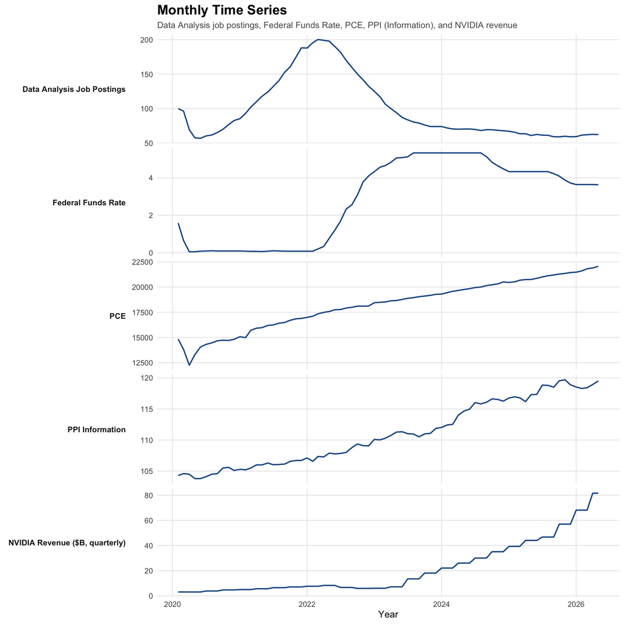

Figure 15. **Monthly time series.** DA job postings and the four predictors on a common monthly axis, each with its own vertical scale.

```r
monthly_long <- df %>%
  pivot_longer(-Date, names_to = "Variable", values_to = "Value") %>%
  mutate(Variable = factor(monthly_variables[Variable], levels = monthly_variables))

fig_monthly <- ggplot(monthly_long, aes(Date, Value)) +
  geom_line(linewidth = 0.8, color = col_actual) +
  facet_grid(Variable ~ ., scales = "free_y", switch = "y") +
  labs(title = "Monthly Time Series",
       subtitle = "Data Analysis job postings, Federal Funds Rate, PCE, PPI (Information), and NVIDIA revenue",
       x = "Year", y = NULL) +
  theme_ts() +
  theme(strip.placement = "outside",
        strip.text.y.left = element_text(angle = 0, hjust = 1))

fig_monthly
save_plot(fig_monthly, "Monthly_time_series.png", width = 11, height = 9)
```

### 6.2.2 Lag plots

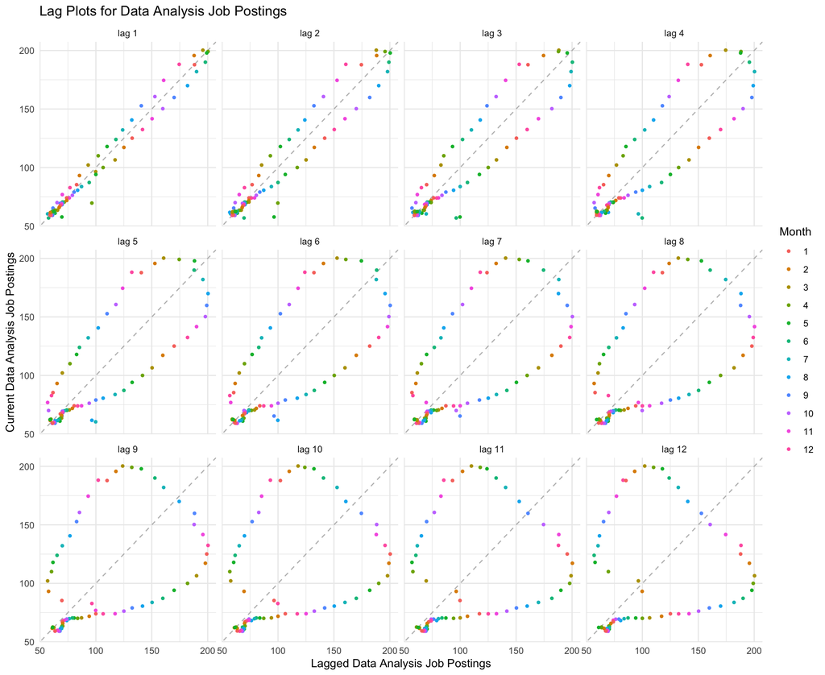

(a) Data Analysis Job Postings

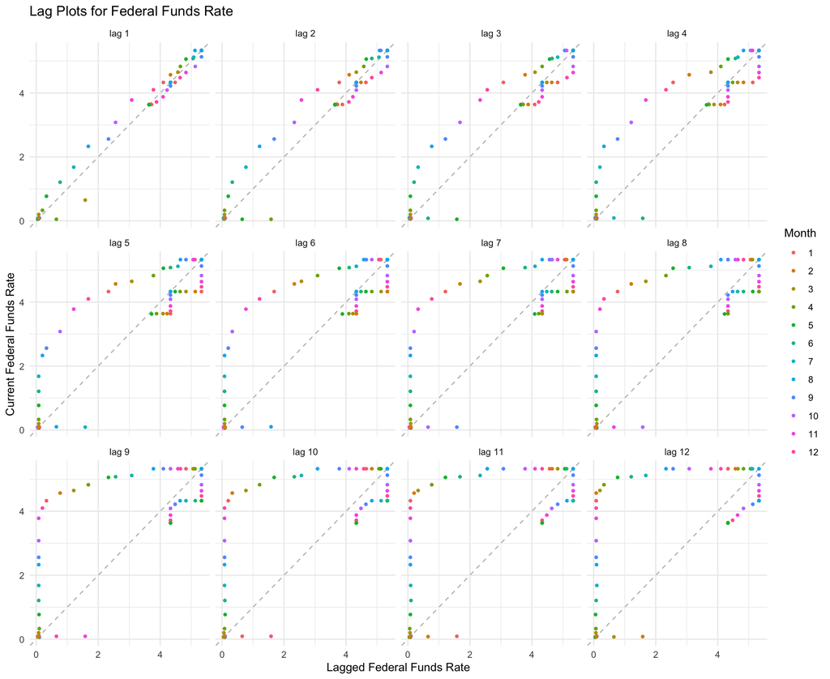

(b) Federal Funds Rate

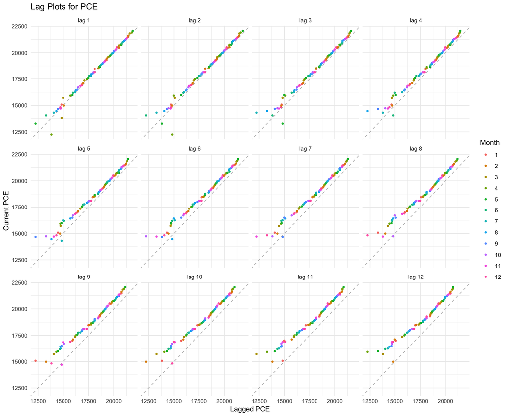

(c) PCE

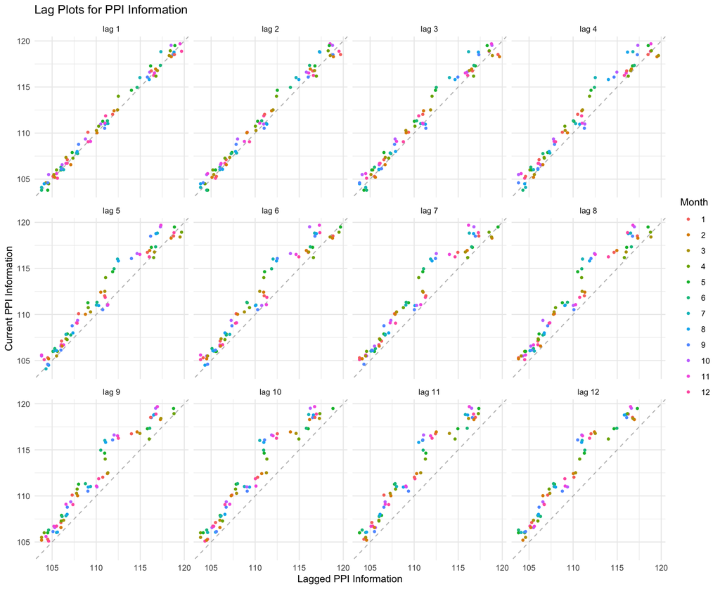

(d) PPI Information

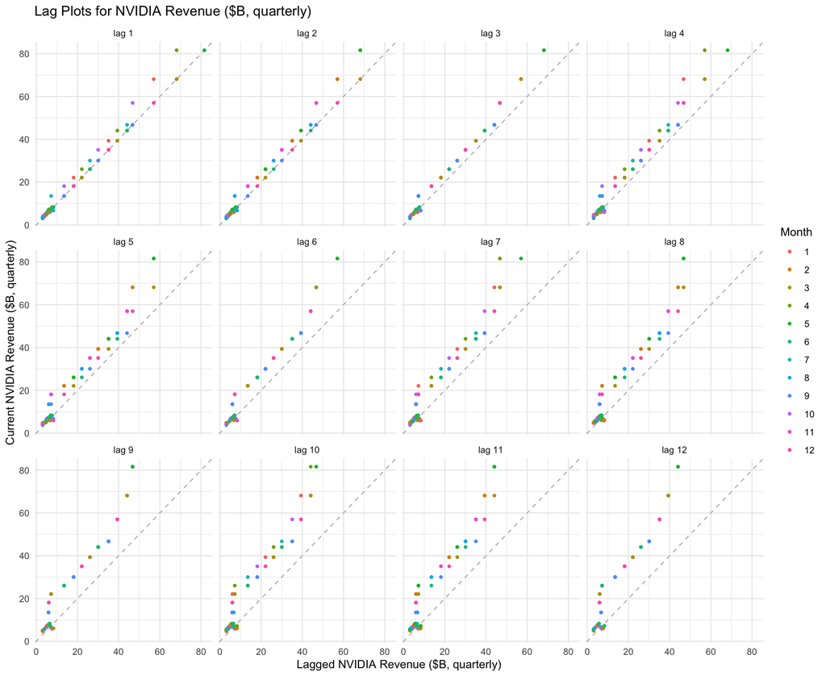

(e) NVIDIA Revenue ($B, quarterly)

Figure 16. **Lag plots.** Each panel plots a series against its own value 1 to 12 months earlier. Tight, straight patterns signal strong dependence on the past, and recurring patterns can reveal yearly cycles.

```r
for (var_name in names(monthly_variables)) {
  p <- gglagplot(df.ts[, var_name], do.lines = FALSE, lags = 12) +
    ggtitle(paste("Lag Plots for", monthly_variables[[var_name]])) +
    xlab(paste("Lagged", monthly_variables[[var_name]])) +
    ylab(paste("Current", monthly_variables[[var_name]])) +
    theme_minimal()
  print(p)
}
```

### 6.2.3 ACF plots

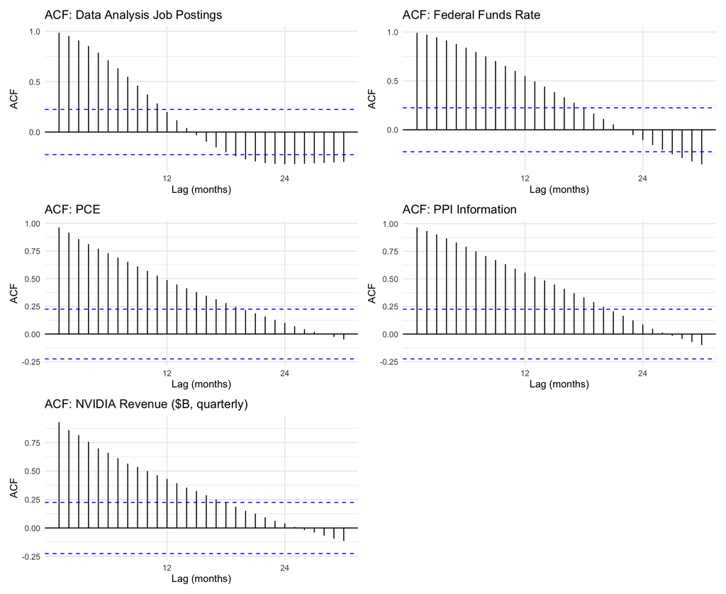

Figure 17. **Autocorrelation of each monthly series.** Correlation of a series with its own past. Slow decay points to a trend, and spikes at multiples of 12 point to yearly seasonality.

```r
acf_plots <- lapply(names(monthly_variables), function(var_name) {
  ggAcf(df.ts[, var_name], lag.max = 30) +
    ggtitle(paste("ACF:", monthly_variables[[var_name]])) +
    xlab("Lag (months)") +
    theme_minimal()
})

wrap_plots(acf_plots, ncol = 2)
```

### 6.2.4 Stationarity (Augmented Dickey–Fuller test)

```r
adf_results <- map_dfr(names(monthly_variables), function(var_name) {
  adf_result <- adf.test(df.ts[, var_name])
  tibble(
    Variable      = monthly_variables[[var_name]],
    ADF_Statistic = as.numeric(adf_result$statistic),
    Lag_Order     = as.numeric(adf_result$parameter),
    P_Value       = adf_result$p.value,
    Conclusion    = if_else(adf_result$p.value < 0.05, "Stationary", "Non-stationary")
  )
})

kable(adf_results, digits = 4) %>%
  kable_styling(full_width = FALSE, bootstrap_options = c("striped", "hover", "condensed"))
```

| Variable | ADF_Statistic | Lag_Order | P_Value | Conclusion |
| --- | --- | --- | --- | --- |
| Data Analysis Job Postings | -4.5443 | 4 | 0.0100 | Stationary |
| Federal Funds Rate | -1.8527 | 4 | 0.6356 | Non-stationary |
| PCE | -2.8296 | 4 | 0.2369 | Non-stationary |
| PPI Information | -2.2205 | 4 | 0.4855 | Non-stationary |
| NVIDIA Revenue ($B, quarterly) | 1.5003 | 4 | 0.9900 | Non-stationary |

Table 14. **Stationarity (ADF) test results.** A p-value below 0.05 means the series has no persistent trend and is stationary. Otherwise it needs differencing or a model that handles trends.

If p-value < 0.05 → reject the unit root → stationary; if p-value ≥ 0.05 → fail to reject → non-stationary.

## 6.3 Fitting the ARIMAX model with `auto.arima()`

```r
y    <- df.ts[, "DataAnalysisJobPostings"]
xreg <- df.ts[, xreg_names]

fit_auto <- auto.arima(y, xreg = xreg)
summary(fit_auto)
```

```
Series: y
Regression with ARIMA(2,0,3)(1,0,0)[12] errors

Coefficients:
         ar1      ar2      ma1      ma2     ma3    sar1  FedFundsRate     PCE
      1.9018  -0.9232  -0.2909  -0.3800  0.4430  0.3324       -6.2244  0.0064
s.e.  0.0631   0.0634   0.1536   0.1415  0.1706  0.1649        3.7083  0.0014
      PPIInformation  NVIDIARevenue
             -0.0266         0.0742
s.e.          0.2693         0.2180

sigma^2 = 13.8:  log likelihood = -206.48
AIC=434.95   AICc=439.08   BIC=460.59

Training set error measures:
                     ME     RMSE     MAE        MPE    MAPE       MASE
Training set -0.1087197 3.461915 2.45302 -0.2957087 2.91481 0.05577763
                   ACF1
Training set 0.06539238
```

```
    Ljung-Box test

data:  Residuals from Regression with ARIMA(2,0,3)(1,0,0)[12] errors
Q* = 10.912, df = 9, p-value = 0.2818

Model df: 6.   Total lags used: 15
```

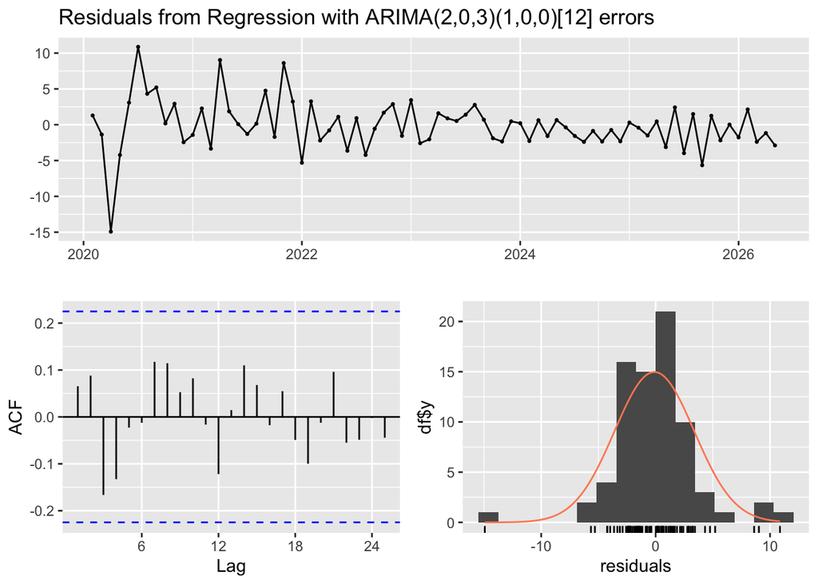

Figure 18. **Residual check for the automatic ARIMAX fit.** Residuals over time, their autocorrelation and their distribution. A good fit leaves patternless noise.

```r
checkresiduals(fit_auto)
```

## 6.4 Fitting the model manually

### 6.4.1 Step 1: Regression

We first fit a linear regression of DA job postings on the four predictors and then model the regression residuals as a (S)ARIMA process.

```r
reg_model <- lm(DataAnalysisJobPostings ~ FedFundsRate + PCE + PPIInformation + NVIDIARevenue, data = df)
summary(reg_model)
```

```
Call:
lm(formula = DataAnalysisJobPostings ~ FedFundsRate + PCE + PPIInformation +
    NVIDIARevenue, data = df)

Residuals:
    Min      1Q  Median      3Q     Max
-33.240 -13.152  -1.468  13.219  69.398

Coefficients:
                Estimate Std. Error t value Pr(>|t|)
(Intercept)    335.00495  220.26779   1.521 0.132727
FedFundsRate   -22.59677    2.26660  -9.969 3.90e-15 ***
PCE              0.04206    0.00316  13.312  < 2e-16 ***
PPIInformation  -8.05944    2.33498  -3.452 0.000943 ***
NVIDIARevenue   -2.16190    0.34751  -6.221 3.04e-08 ***
---
Signif. codes:  0 '***' 0.001 '**' 0.01 '*' 0.05 '.' 0.1 ' ' 1

Residual standard error: 18.87 on 71 degrees of freedom
Multiple R-squared:  0.8302,    Adjusted R-squared:  0.8206
F-statistic: 86.76 on 4 and 71 DF,  p-value: < 2.2e-16
```

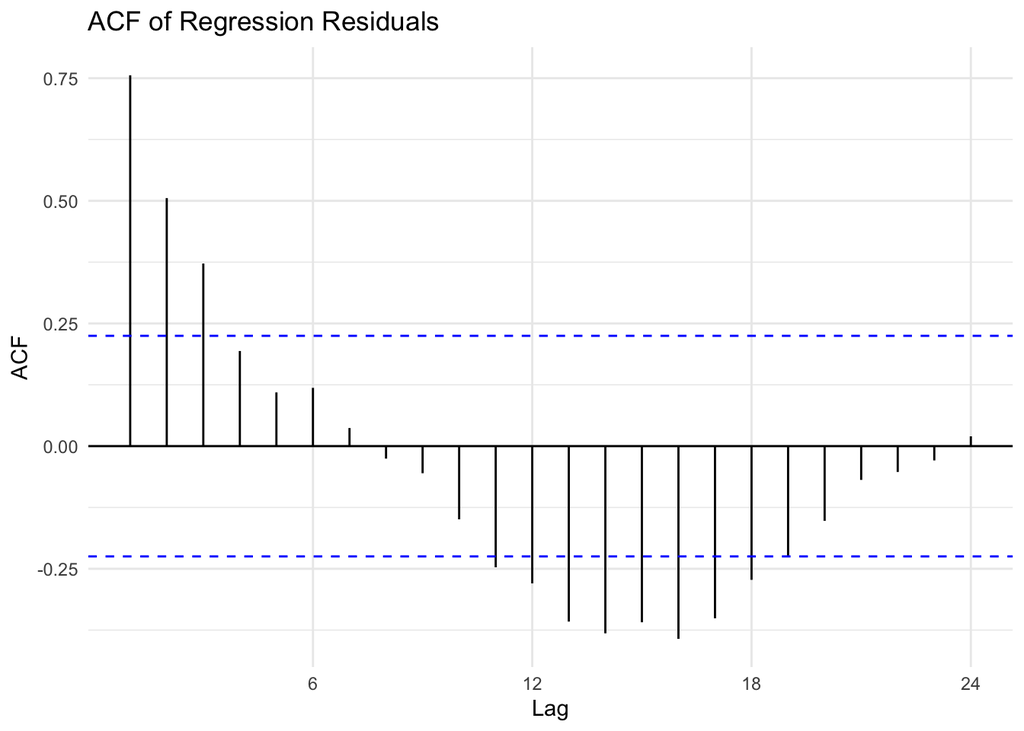

Figure 19. **ACF of the regression residuals.** Strong autocorrelation shows that the plain regression misses time structure, which the SARIMA error model must capture.

```r
res.fit <- ts(residuals(reg_model), start = c(start_year, start_month), frequency = 12)

ggAcf(res.fit) + ggtitle("ACF of Regression Residuals") + theme_minimal()
```

In this plain regression every predictor, including NVIDIA revenue, looks highly significant. These p-values are overstated, because the residuals are strongly autocorrelated (see the ACF above) and both NVIDIA revenue and job postings trend over time. The ARIMAX estimates below, which model the error structure, are the ones to rely on.

```r
# Check: automatic order selection for the residuals
auto.arima(res.fit)
```

```
Series: res.fit
ARIMA(5,0,0)(0,0,1)[12] with zero mean

Coefficients:
         ar1      ar2     ar3      ar4     ar5    sma1
      0.9868  -0.4830  0.7795  -0.9232  0.3452  -0.452
s.e.  0.1107   0.1336  0.1308   0.1665  0.1483   0.205

sigma^2 = 101.5:  log likelihood = -282.9
AIC=579.8   AICc=581.44   BIC=596.11
```

### 6.4.2 Step 2: Identify the error model

#### 6.4.2.1 First-order differencing

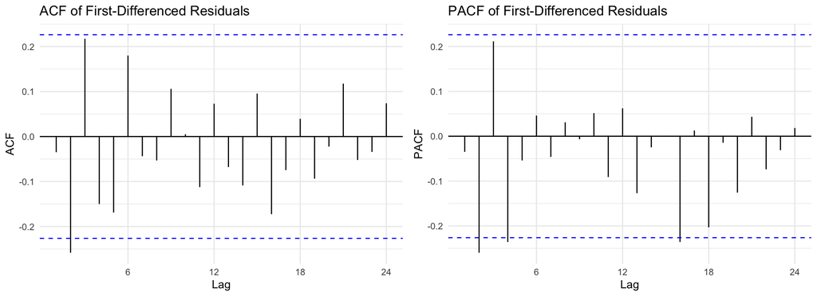

Figure 20. **ACF and PACF after first differencing.** Used to judge how many autoregressive and moving-average terms the error model needs once the trend is removed.

```r
first_diff <- diff(res.fit)

grid.arrange(
  ggAcf(first_diff)  + ggtitle("ACF of First-Differenced Residuals")  + theme_minimal(),
  ggPacf(first_diff) + ggtitle("PACF of First-Differenced Residuals") + theme_minimal(),
  ncol = 2
)
```

No additional ordinary differencing appears necessary, so $d = 0$ is a candidate (with $d = 1$ also considered).

#### 6.4.2.2 Residuals without differencing

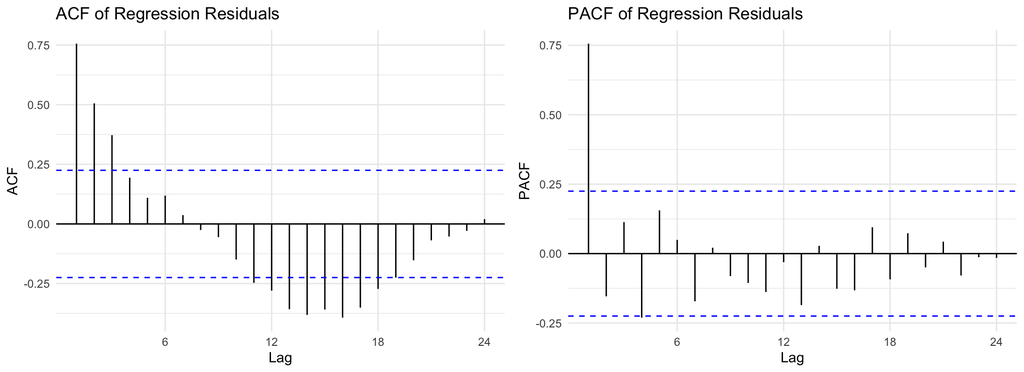

Figure 21. **ACF and PACF with no differencing.** Suggests candidate non-seasonal orders (p and q) directly from the regression residuals.

```r
grid.arrange(
  ggAcf(res.fit)  + ggtitle("ACF of Regression Residuals")  + theme_minimal(),
  ggPacf(res.fit) + ggtitle("PACF of Regression Residuals") + theme_minimal(),
  ncol = 2
)
```

From the ACF: $q = 1, 2, 3, 4$; from the PACF: $p = 1$.

#### 6.4.2.3 Seasonal differencing only

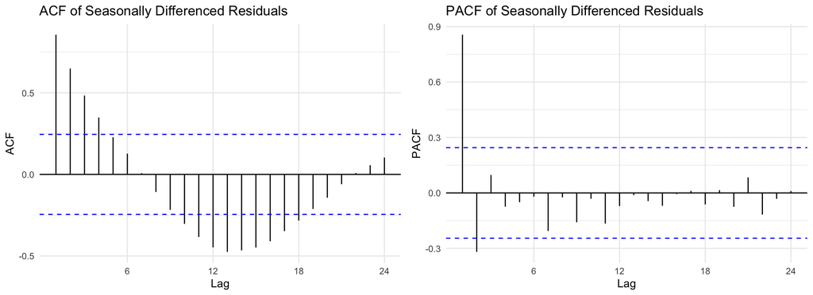

Figure 22. **ACF and PACF after seasonal differencing.** Removing the 12-month cycle highlights the seasonal terms (P and Q).

```r
seasonal_diff <- diff(res.fit, lag = 12)

grid.arrange(
  ggAcf(seasonal_diff)  + ggtitle("ACF of Seasonally Differenced Residuals")  + theme_minimal(),
  ggPacf(seasonal_diff) + ggtitle("PACF of Seasonally Differenced Residuals") + theme_minimal(),
  ncol = 2
)
```

From the PACF: $P = 1$; from the ACF: $Q = 1$; one seasonal difference: $D = 1$.

#### 6.4.2.4 Seasonal differencing on top of first differencing

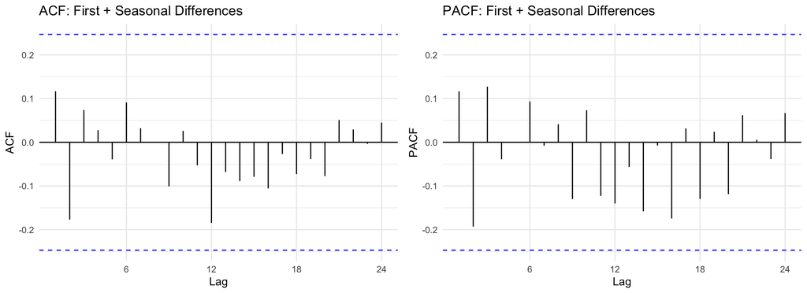

Figure 23. **ACF and PACF after first and seasonal differencing.** The most heavily differenced version, used to check whether both kinds of differencing are needed.

```r
both_diff <- diff(first_diff, lag = 12)

grid.arrange(
  ggAcf(both_diff)  + ggtitle("ACF: First + Seasonal Differences")  + theme_minimal(),
  ggPacf(both_diff) + ggtitle("PACF: First + Seasonal Differences") + theme_minimal(),
  ncol = 2
)
```

Here $d = 1, D = 1, P = 1, Q = 1$.

**Candidate parameters:** $d \in \{0, 1\}$, $p = 1$, $q \in \{1, \dots, 4\}$, $D = 1$, $P \in \{0,1\}$, $Q \in \{0,1\}$.

## 6.5 Parameter tuning

### 6.5.1 Non-seasonal ARIMA search

```r
p_range <- 1:4
d_range <- 0:1
q_range <- 1

arima_search <- expand_grid(p = p_range, d = d_range, q = q_range) %>%
  mutate(fit = pmap(list(p, d, q), function(p, d, q) {
    tryCatch(Arima(res.fit, order = c(p, d, q), include.drift = TRUE),
             error = function(e) NULL)
  })) %>%
  filter(!map_lgl(fit, is.null)) %>%
  mutate(AIC  = map_dbl(fit, "aic"),
         BIC  = map_dbl(fit, "bic"),
         AICc = map_dbl(fit, "aicc")) %>%
  select(-fit) %>%
  arrange(AIC)

top_arima <- head(arima_search, 10)

kable(top_arima, digits = 3, align = "c") %>%
  kable_styling(full_width = FALSE) %>%
  row_spec(which.min(top_arima$AIC), bold = TRUE, background = "#FFFF99")
```

| p | d | q | AIC | BIC | AICc |
| --- | --- | --- | --- | --- | --- |
| 4 | 1 | 1 | 582.039 | 598.261 | 583.710 |
| 3 | 1 | 1 | 583.159 | 597.064 | 584.395 |
| 2 | 1 | 1 | 585.073 | 596.660 | 585.942 |
| 4 | 0 | 1 | 586.303 | 604.949 | 588.453 |
| 1 | 1 | 1 | 591.615 | 600.885 | 592.186 |
| 3 | 0 | 1 | 593.313 | 609.628 | 594.960 |
| 2 | 0 | 1 | 595.085 | 609.070 | 596.303 |
| 1 | 0 | 1 | 597.094 | 608.747 | 597.951 |

### 6.5.2 Seasonal ARIMA (SARIMA) search

```r
SARIMA.c <- function(p1, p2, q1, q2, P1, P2, Q1, Q2, data, d = 0, D = 1, s = 12) {

  results <- list()

  for (p in p1:p2) for (q in q1:q2) for (P in P1:P2) for (Q in Q1:Q2) {

    if (p + d + q + P + D + Q <= 10) {

      model <- tryCatch(
        Arima(data, order = c(p, d, q),
              seasonal = list(order = c(P, D, Q), period = s)),
        error = function(e) NULL
      )

      if (!is.null(model)) {
        results[[length(results) + 1]] <- tibble(
          p = p, d = d, q = q, P = P, D = D, Q = Q,
          AIC = model$aic, BIC = model$bic, AICc = model$aicc
        )
      }
    }
  }

  if (length(results) == 0) stop("No SARIMA models were successfully fitted.")
  bind_rows(results)
}

sarima_output <- SARIMA.c(p1 = 0, p2 = 1, q1 = 1, q2 = 4,
                          P1 = 0, P2 = 1, Q1 = 0, Q2 = 1, data = res.fit)

top_sarima <- sarima_output %>% arrange(AIC) %>% head(10)

kable(top_sarima, digits = 3, align = "c") %>%
  kable_styling(full_width = FALSE) %>%
  row_spec(which.min(top_sarima$AIC), bold = TRUE, background = "#FFFF99")
bind_rows(
  "Best by AIC" = slice_min(sarima_output, AIC, n = 1, with_ties = FALSE),
  "Best by BIC" = slice_min(sarima_output, BIC, n = 1, with_ties = FALSE),
  .id = "Selection_Criterion"
) %>%
  kable(digits = 3, align = "c") %>%
  kable_styling(full_width = FALSE, bootstrap_options = c("striped", "hover", "condensed"))
```

| p | d | q | P | D | Q | AIC | BIC | AICc |
| --- | --- | --- | --- | --- | --- | --- | --- | --- |
| 0 | 0 | 4 | 0 | 1 | 1 | 513.493 | 526.447 | 514.967 |
| 1 | 0 | 4 | 0 | 1 | 1 | 514.495 | 529.607 | 516.495 |
| 0 | 0 | 4 | 1 | 1 | 1 | 515.399 | 530.511 | 517.399 |
| 1 | 0 | 1 | 1 | 1 | 0 | 515.505 | 524.141 | 516.183 |
| 1 | 0 | 1 | 0 | 1 | 1 | 515.511 | 524.146 | 516.189 |
| 1 | 0 | 2 | 0 | 1 | 1 | 516.661 | 527.456 | 517.696 |
| 1 | 0 | 2 | 1 | 1 | 0 | 516.681 | 527.476 | 517.716 |
| 1 | 0 | 1 | 1 | 1 | 1 | 517.324 | 528.118 | 518.358 |
| 1 | 0 | 4 | 1 | 1 | 1 | 517.765 | 535.036 | 520.383 |
| 0 | 0 | 4 | 1 | 1 | 0 | 517.846 | 530.799 | 519.320 |

(a) Top 10 SARIMA models by AIC

| Selection_Criterion | p | d | q | P | D | Q | AIC | BIC | AICc |
| --- | --- | --- | --- | --- | --- | --- | --- | --- | --- |
| Best by AIC | 0 | 0 | 4 | 0 | 1 | 1 | 513.493 | 526.447 | 514.967 |
| Best by BIC | 1 | 0 | 1 | 1 | 1 | 0 | 515.505 | 524.141 | 516.183 |

(b) Best SARIMA models by AIC and by BIC

Table 16. **Seasonal ARIMA (SARIMA) search.** Candidate seasonal error models for the regression residuals, ranked by AIC and BIC (lower is better).

### 6.5.3 Candidate models

- ARIMA(1,0,1)
- ARIMA(3,1,1)
- SARIMA(1,0,1)(0,1,1)[12]
- SARIMA(1,0,1)(1,1,1)[12]

## 6.6 Time-series cross-validation

The two seasonal candidates are compared with an expanding-window cross-validation. The initial training window is roughly one-third of the sample (rounded down to whole years), and 12-month-ahead forecasts are produced at every origin.

```r
y_cv <- res.fit
n    <- length(y_cv)
k    <- floor(n / 3 / 12) * 12   # initial training window
h    <- 12                       # forecast horizon (months)

n_origins <- n - k - h + 1

if (k < 24)        warning("The initial training window contains fewer than two seasonal cycles.")
if (n_origins < 1) stop("There are not enough observations for 12-step cross-validation.")

cv_models <- list(
  "SARIMA(1,0,1)(0,1,1)[12]" = list(order = c(1, 0, 1), seasonal = c(0, 1, 1)),
  "SARIMA(1,0,1)(1,1,1)[12]" = list(order = c(1, 0, 1), seasonal = c(1, 1, 1))
)

cv_errors <- lapply(cv_models, function(x) matrix(NA_real_, nrow = n_origins, ncol = h))

for (i in seq_len(n_origins)) {

  train_end <- k + i - 1
  xtrain    <- window(y_cv, end = time(y_cv)[train_end])
  xtest     <- as.numeric(y_cv[(train_end + 1):(train_end + h)])

  for (model_name in names(cv_models)) {
    spec <- cv_models[[model_name]]
    fit_i <- tryCatch(
      Arima(xtrain, order = spec$order,
            seasonal = list(order = spec$seasonal, period = 12), method = "ML"),
      error = function(e) NULL
    )
    if (!is.null(fit_i)) {
      cv_errors[[model_name]][i, ] <- as.numeric(forecast(fit_i, h = h)$mean) - xtest
    }
  }
}

rmse_table <- tibble(Horizon = 1:h) %>%
  bind_cols(map_dfc(cv_errors, ~ sqrt(colMeans(.x^2, na.rm = TRUE))))

kable(rmse_table, digits = 4) %>%
  kable_styling(full_width = FALSE, bootstrap_options = c("striped", "hover", "condensed"))
```

| Horizon | SARIMA(1,0,1)(0,1,1)[12] | SARIMA(1,0,1)(1,1,1)[12] |
| --- | --- | --- |
| 1 | 10.5098 | 12.4431 |
| 2 | 13.1755 | 17.4064 |
| 3 | 15.4676 | 19.1660 |
| 4 | 17.7222 | 20.0757 |
| 5 | 18.7416 | 21.8530 |
| 6 | 18.5519 | 21.8819 |
| 7 | 18.3112 | 21.6922 |
| 8 | 17.6362 | 21.0671 |
| 9 | 16.8705 | 19.9818 |
| 10 | 16.4078 | 19.3831 |
| 11 | 16.4738 | 19.1015 |
| 12 | 16.7896 | 18.1866 |

Table 17. **Rolling-origin cross-validation error.** Forecast error (RMSE) for each months-ahead horizon, for the two SARIMA candidates. Lower is better.

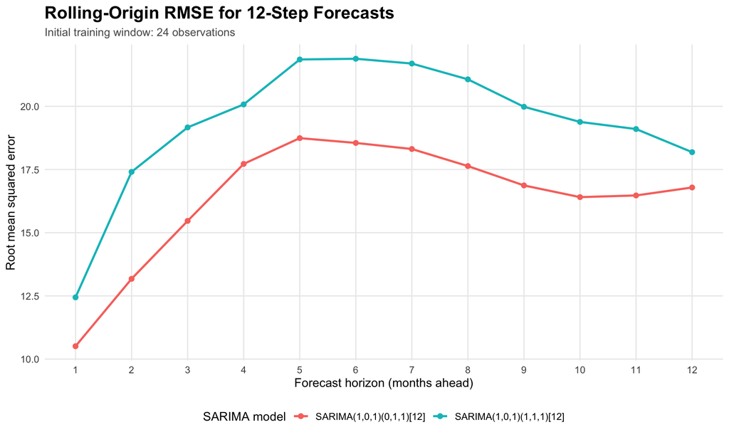

Figure 24. **Cross-validation error by forecast horizon.** Lower curves mean more accurate forecasts. The SARIMA candidate that stays lower across horizons is preferred.

```r
fig_cv <- rmse_table %>%
  pivot_longer(-Horizon, names_to = "Model", values_to = "RMSE") %>%
  ggplot(aes(Horizon, RMSE, color = Model)) +
  geom_line(linewidth = 1) +
  geom_point(size = 2) +
  scale_x_continuous(breaks = 1:h) +
  labs(title = "Rolling-Origin RMSE for 12-Step Forecasts",
       subtitle = paste("Initial training window:", k, "observations"),
       x = "Forecast horizon (months ahead)", y = "Root mean squared error",
       color = "SARIMA model") +
  theme_ts()

fig_cv
save_plot(fig_cv, "Monthly_CV_RMSE.png", width = 10, height = 6)
```

## 6.7 Model diagnostics

```
### ARIMA(1,0,1) ###
Coefficients:
      Estimate     SE t.value p.value
ar1     0.5936 0.1776  3.3415  0.0013
ma1     0.4054 0.2924  1.3862  0.1699
xmean   0.8295 4.4586  0.1860  0.8529

sigma^2 estimated as 130.7575 on 73 degrees of freedom

AIC = 7.830237  AICc = 7.834623  BIC = 7.952907
```

```
### ARIMA(3,1,1) ###
Coefficients:
         Estimate     SE t.value p.value
ar1       -0.2789 0.2063 -1.3519  0.1808
ar2       -0.3473 0.1178 -2.9486  0.0043
ar3        0.3513 0.1601  2.1940  0.0316
ma1        0.3510 0.1994  1.7601  0.0828
constant  -0.3023 1.3211 -0.2289  0.8196

sigma^2 estimated as 117.0265 on 70 degrees of freedom

AIC = 7.775457  AICc = 7.787052  BIC = 7.960856
```

```
### SARIMA(1,0,1)(0,1,1)[12] ###
Coefficients:
         Estimate     SE t.value p.value
ar1        0.7440 0.1059  7.0262  0.0000
ma1        0.3324 0.1666  1.9947  0.0506
sma1      -0.4459 0.1975 -2.2577  0.0276
constant   0.0278 0.4155  0.0670  0.9468

sigma^2 estimated as 152.8447 on 60 degrees of freedom

AIC = 8.086035  AICc = 8.096628  BIC = 8.254698
```

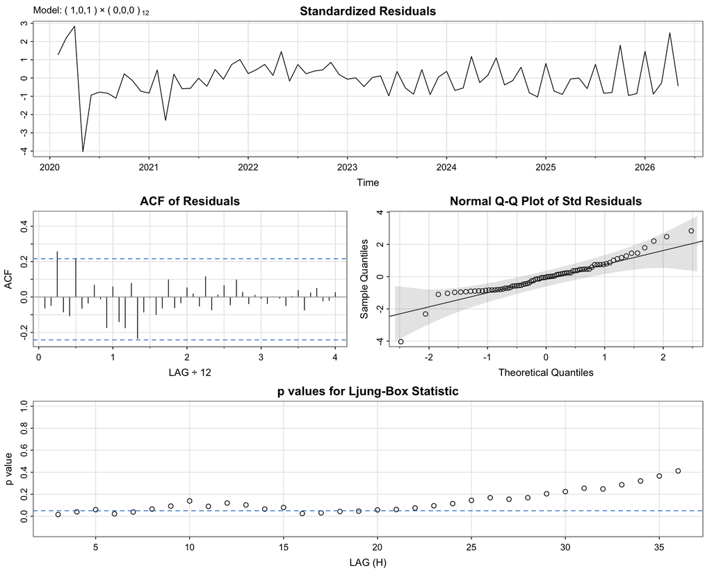

(a) ARIMA(1,0,1)

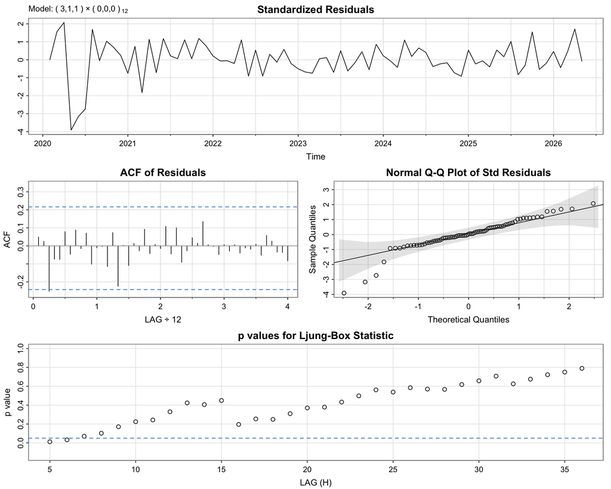

(b) ARIMA(3,1,1)

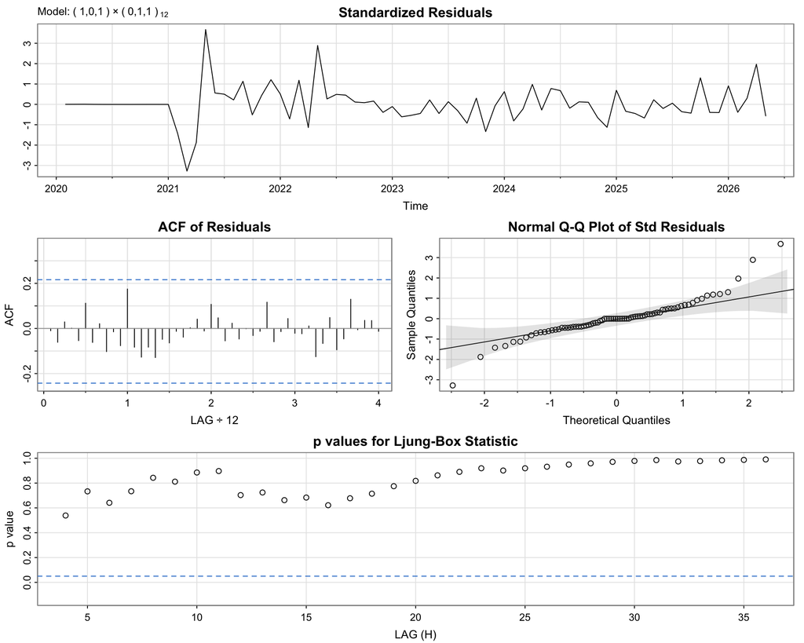

(c) SARIMA(1,0,1)(0,1,1)[12]

Figure 25. **Residual diagnostics for the candidate error models.** Each set shows standardized residuals, their autocorrelation, a normal Q-Q plot and Ljung-Box p-values. A good model leaves patternless residuals and p-values above 0.05.

```r
set.seed(345)

diagnostic_models <- list(
  "ARIMA(1,0,1)"             = c(1, 0, 1, 0, 0, 0),
  "ARIMA(3,1,1)"             = c(3, 1, 1, 0, 0, 0),
  "SARIMA(1,0,1)(0,1,1)[12]" = c(1, 0, 1, 0, 1, 1)
)

for (model_name in names(diagnostic_models)) {
  o <- diagnostic_models[[model_name]]
  model_output <- capture.output(
    sarima(res.fit, o[1], o[2], o[3], o[4], o[5], o[6], 12)
  )
  start_line <- grep("Coefficients", model_output)
  start_line <- if (length(start_line) == 0) 1 else start_line[1]
  cat("\n###", model_name, "###\n")
  cat(model_output[start_line:length(model_output)], sep = "\n")
}
```

**Interpretation** (update after re-running):

- **Standardized residuals** fluctuate around zero with roughly constant variance, consistent with a stationary error process.
- **ACF of residuals** shows no significant autocorrelation, indicating that the error structure has been captured.
- **Q–Q plot** suggests approximately normal residuals with minor deviations in the tails.
- **Ljung–Box p-values** remain mostly above 0.05, indicating no remaining autocorrelation.
- **Coefficient significance:** check the p-values above; in the selected SARIMA(1,0,1)(0,1,1)[12] model the AR and seasonal MA terms are significant and the MA term is borderline (p ≈ 0.05).

## 6.8 Final model

```r
fit <- Arima(
  y,
  order    = c(1, 0, 1),
  seasonal = list(order = c(0, 1, 1), period = 12),
  xreg     = xreg
)

summary(fit)
```

```
Series: y
Regression with ARIMA(1,0,1)(0,1,1)[12] errors

Coefficients:
         ar1     ma1     sma1  FedFundsRate     PCE  PPIInformation
      0.9901  0.8491  -0.7857       -8.0750  0.0059         -0.7164
s.e.  0.0177  0.0827   0.3151        3.9054  0.0018          0.6655
      NVIDIARevenue
             0.3306
s.e.         0.2443

sigma^2 = 23.56:  log likelihood = -195.82
AIC=407.63   AICc=410.25   BIC=424.91

Training set error measures:
                    ME     RMSE     MAE        MPE     MAPE       MASE
Training set -0.310275 4.203875 2.92827 -0.6038935 3.002553 0.06658403
                  ACF1
Training set 0.2570337
```

```r
# Coefficients used in the model equation below
round(coef(fit), 4)
```

```
           ar1            ma1           sma1   FedFundsRate            PCE
        0.9901         0.8491        -0.7857        -8.0750         0.0059
PPIInformation  NVIDIARevenue
       -0.7164         0.3306
```

### 6.8.1 Does NVIDIA revenue help?

The same SARIMA error structure is refitted for each job-opening series with and without NVIDIA revenue. Software and overall job openings are built exactly like the DA series, from the daily Indeed files aggregated to monthly averages.

```r
read_job_index <- function(file, name) {
  x <- read.csv(file.path(data_folder, file))[, 1:2]
  colnames(x) <- c("Date", name)
  x$Date <- as.Date(x$Date)
  x
}

job_series <- list(
  "DA job openings"  = list(data = indeed_da,
                            order = c(1, 0, 1), seasonal = c(0, 1, 1)),
  "SW job openings"  = list(data = read_job_index("indeed-software.csv", "JobPostings"),
                            order = c(1, 0, 1), seasonal = c(0, 1, 1)),
  "ALL job openings" = list(data = read_job_index("indeed-all.csv", "JobPostings"),
                            order = c(0, 1, 1), seasonal = c(0, 1, 1))
)

fit_job_model <- function(spec, xnames) {
  d <- build_monthly(spec$data)
  y_name <- setdiff(names(d), c("Date", xreg_names))
  t_ <- ts(d[, -1], start = c(year(min(d$Date)), month(min(d$Date))), frequency = 12)
  Arima(t_[, y_name], order = spec$order,
        seasonal = list(order = spec$seasonal, period = 12),
        xreg = t_[, xnames, drop = FALSE])
}

job_fits <- lapply(job_series, function(spec) {
  list(with_nvidia    = fit_job_model(spec, xreg_names),
       without_nvidia = fit_job_model(spec, setdiff(xreg_names, "NVIDIARevenue")))
})

nvidia_check <- imap_dfr(job_fits, function(f, job) {
  est <- coef(f$with_nvidia)["NVIDIARevenue"]
  se  <- sqrt(diag(vcov(f$with_nvidia)))["NVIDIARevenue"]
  tibble(
    Series                 = job,
    `NVIDIA coefficient`   = est,
    `Std. error`           = se,
    `z`                    = est / se,
    `p-value`              = 2 * pnorm(-abs(est / se)),
    `AICc without NVIDIA`  = f$without_nvidia$aicc,
    `AICc with NVIDIA`     = f$with_nvidia$aicc,
    `Better AICc`          = if_else(f$with_nvidia$aicc < f$without_nvidia$aicc,
                                     "With NVIDIA", "Without NVIDIA")
  )
})

save_table(nvidia_check, "Monthly_NVIDIA_check.csv")

kable(nvidia_check, digits = 3) %>%
  kable_styling(full_width = FALSE, bootstrap_options = c("striped", "hover", "condensed"))
```

| Series | NVIDIA coefficient | Std. error | z | p-value | AICc without NVIDIA | AICc with NVIDIA | Better AICc |
| --- | --- | --- | --- | --- | --- | --- | --- |
| DA job openings | 0.331 | 0.244 | 1.353 | 0.176 | 409.356 | 410.252 | Without NVIDIA |
| SW job openings | 0.501 | 0.267 | 1.879 | 0.060 | 425.631 | 424.674 | With NVIDIA |
| ALL job openings | 0.103 | 0.171 | 0.605 | 0.545 | 349.939 | 352.110 | Without NVIDIA |

Table 18. **Does NVIDIA revenue help?** The estimated NVIDIA effect (US$ billions per quarter) for each job series, how statistically strong it is, and AICc with and without it. A lower AICc means the better model.

### 6.8.2 Model equations

```r
reg_eq <- function(fit) {
  b      <- coef(fit)[xreg_names]
  terms  <- paste0(sprintf("%.4f", abs(b)), "\\,\\text{", xreg_names, "}_t")
  signs  <- if_else(b < 0, "-", "+")
  lines  <- paste0(signs, " ", terms)
  lines[1] <- sub("^\\+ ", "", lines[1])
  paste0("\\begin{aligned} y_t &= ", lines[1], " \\\\ &\\quad ",
         paste(lines[-1], collapse = " \\\\ &\\quad "), " \\\\ &\\quad + n_t \\end{aligned}")
}

signed_term <- function(x, symbol, power = "") {
  paste0(if_else(x < 0, "-", "+"), sprintf("%.4f", abs(x)), symbol, power)
}

error_terms <- function(fit, ar = TRUE) {
  co  <- coef(fit)
  lhs <- paste0(if (ar) paste0("(1", signed_term(-co["ar1"], "B"), ")") else "(1-B)", "(1-B^{12})")
  rhs <- paste0("(1", signed_term(co["ma1"], "B"), ")(1", signed_term(co["sma1"], "B", "^{12}"), ")")
  paste0(lhs, "\\,n_t = ", rhs, "\\,w_t")
}

fit_da  <- job_fits[["DA job openings"]]$with_nvidia
fit_sw  <- job_fits[["SW job openings"]]$with_nvidia
fit_all <- job_fits[["ALL job openings"]]$with_nvidia
```

**NoteDA Job Openings: Regression with SARIMA(1,0,1)(0,1,1)[12] Errors**

$$y_t = \beta_1 X_{1t} + \beta_2 X_{2t} + \beta_3 X_{3t} + \beta_4 X_{4t} + n_t$$

where $y_t$ is **Data Analysis Job Postings**, $X_1$ to $X_4$ are the Federal Funds Rate, PCE, PPI (Information), and NVIDIA revenue (US$ billions), and $n_t$ is the SARIMA error term. With the estimated regression coefficients:

$$\begin{aligned} y_t &= - 8.0750\,\text{FedFundsRate}_t \\ &\quad + 0.0059\,\text{PCE}_t \\ &\quad - 0.7164\,\text{PPIInformation}_t \\ &\quad + 0.3306\,\text{NVIDIARevenue}_t \\ &\quad + n_t \end{aligned}$$

The error term follows

$$\Phi_P(B^{12})\,\varphi(B)\,\nabla_{12}^{1}\nabla^{0} n_t = \Theta_Q(B^{12})\,\theta(B)\,w_t,$$

which for the selected model is

$$(1-\phi_1B)(1-B^{12})\,n_t = (1+\theta_1B)(1+\Theta_1B^{12})\,w_t$$

$$(1-0.9901B)(1-B^{12})\,n_t = (1+0.8491B)(1-0.7857B^{12})\,w_t$$

The same workflow applied to software and overall job openings produced the following models:

**NoteSW Job Openings: Regression with SARIMA(1,0,1)(0,1,1)[12] Errors**

$$\begin{aligned} y_t &= - 12.5258\,\text{FedFundsRate}_t \\ &\quad + 0.0032\,\text{PCE}_t \\ &\quad - 1.2153\,\text{PPIInformation}_t \\ &\quad + 0.5013\,\text{NVIDIARevenue}_t \\ &\quad + n_t \end{aligned}$$

$$(1-0.9940B)(1-B^{12})\,n_t = (1+0.8783B)(1-0.9999B^{12})\,w_t$$

**NoteAll Job Openings: Regression with SARIMA(0,1,1)(0,1,1)[12] Errors**

$$\begin{aligned} y_t &= - 1.2651\,\text{FedFundsRate}_t \\ &\quad + 0.0067\,\text{PCE}_t \\ &\quad + 0.2728\,\text{PPIInformation}_t \\ &\quad + 0.1032\,\text{NVIDIARevenue}_t \\ &\quad + n_t \end{aligned}$$

$$(1-B)(1-B^{12})\,n_t = (1+0.8296B)(1-0.6655B^{12})\,w_t$$

## 6.9 Forecasting

Each exogenous variable is first forecast with its own `auto.arima` model; those forecasts are then used as future regressors for the ARIMAX forecast of DA job postings.

```r
monthly_h <- 36

fxreg <- sapply(xreg_names, function(var_name) {
  as.numeric(forecast(auto.arima(xreg[, var_name]), h = monthly_h)$mean)
})

fcast <- forecast(fit, xreg = fxreg, h = monthly_h)
```

```r
future_months <- seq(max(df$Date) %m+% months(1), by = "month", length.out = monthly_h)

fcast_df <- tibble(
  Date     = future_months,
  Forecast = as.numeric(fcast$mean),
  Lower80  = as.numeric(fcast$lower[, 1]), Upper80 = as.numeric(fcast$upper[, 1]),
  Lower95  = as.numeric(fcast$lower[, 2]), Upper95 = as.numeric(fcast$upper[, 2])
)

orig_df <- tibble(Date = df$Date, Actual = as.numeric(y))

plot_ly() %>%
  add_ribbons(data = fcast_df, x = ~Date, ymin = ~Lower95, ymax = ~Upper95,
              name = "95% PI", fillcolor = "rgba(66,146,198,0.2)",
              line = list(color = "transparent")) %>%
  add_ribbons(data = fcast_df, x = ~Date, ymin = ~Lower80, ymax = ~Upper80,
              name = "80% PI", fillcolor = "rgba(66,146,198,0.35)",
              line = list(color = "transparent")) %>%
  add_lines(data = orig_df, x = ~Date, y = ~Actual, name = "Actual",
            line = list(color = col_actual)) %>%
  add_lines(data = fcast_df, x = ~Date, y = ~Forecast, name = "Forecast",
            line = list(color = col_pred)) %>%
  layout(title = "Forecast of Data Analysis Job Postings for the Next 36 Months",
         xaxis = list(title = "Year"),
         yaxis = list(title = "Data Analysis Job Postings Index"))
```

[interactive chart not shown]

Figure 26. **36-month forecast of DA job postings.** The red line is the forecast from the final ARIMAX model, with 80% and 95% prediction bands. The future values of the predictors were themselves forecast.

# 7 Conclusions

- All Job Openings: best test-period model was ARIMAX: CAPEX + PPI (RMSE = 0.61, -1.0% vs. ARIMA baseline)
- DA Job Openings: best test-period model was ARIMAX: NVIDIA Revenue (RMSE = 1.67, -3.8% vs. ARIMA baseline)
- SW Job Openings: best test-period model was ARIMA (baseline) (RMSE = 0.21, +0.0% vs. ARIMA baseline)

**Limitations**

- ARIMAX test forecasts use observed predictor values (ex-post); operational forecasts would require forecasting the predictors as well (as done in Part 3).
- CAPEX and PPI are interpolated to a daily frequency, which smooths their dynamics.
- NVIDIA revenue is reported quarterly. It is carried forward across each quarter’s days and months, so it moves in steps, and each quarter’s figure is assigned from the quarter-end month, before it would actually have been published.
- CCF and regression results describe association, not causation.